# CIRCULATE Galaxy cohort B Ando et al 2024

library(swimplot) library(coxphf) library(grid) library(gtable) library(readr) library(mosaic) library(dplyr) library(officer) library(flextable) library(survival) library(survminer) library(gridtext) library(ggplot2) library(scales) library(ggthemes) library(tidyverse) library(gtsummary) library(flextable) library(parameters) library(car) library(grid) library(ComplexHeatmap) library(readxl) library(janitor) library(rms) library(DT)

#Demographics Table

```r
rm(list=ls())
setwd("~/Downloads")
circ_data <- read.csv("Galaxy Data_20240603 Complete Dataset.csv")
circ_data <- circ_data[circ_data$CohortB=="TRUE",]

circ_data_subset <- circ_data %>%
  select(
    Age,
    Gender,
    ECOG,
    pT,
    pN,
    Stage,
    ACT,
    BRAF.V600E,
    RAS,
    MSI,
    RFS.Event,
    OS.Event,
    OS.months) %>%
  mutate(
    Age = as.numeric(Age),
    Gender = factor(Gender, levels = c("Male", "Female")),
    ECOG = factor(ECOG, levels = c(0, 1)),
    pT = factor(pT, levels = c("T1-T2", "T3-T4")),
    pN = factor(pN, levels = c("N0", "N1-N2")),
    Stage = factor(Stage, levels = c("II", "III")),
    ACT = factor(ACT, levels = c("TRUE", "FALSE"), labels = c("Adjuvant Chemotherapy", "Observation")),
    BRAF.V600E = factor(BRAF.V600E, levels = c("WT", "MUT"), labels = c("BRAF wt", "BRAF V600E")),
    RAS = factor(RAS, levels = c("WT", "MUT"), labels = c("RAS wt", "RAS mut")),
    MSI = factor(MSI, levels = c("MSS", "MSI-High")),
    RFS.Event = factor(RFS.Event, levels = c("TRUE", "FALSE"), labels = c("Recurrence", "No Recurrence")),
    OS.Event = factor(OS.Event, levels = c("TRUE", "FALSE"), labels = c("Deceased", "Alive")),
    OS.months = as.numeric(OS.months))
table1 <- circ_data_subset %>%
  tbl_summary(
    statistic = list(
      all_continuous() ~ "{median} ({min} - {max})",
      all_categorical() ~ "{n} ({p}%)")) %>%
  bold_labels()
table1
```

| **Characteristic** | **N = 250**<sup>1</sup> |
| --- | --- |
| Age | 67 (38 - 92) |
| Gender |  |
| Male | 162 (65%) |
| Female | 88 (35%) |
| ECOG |  |
| 0 | 228 (91%) |
| 1 | 22 (8.8%) |
| pT |  |
| T1-T2 | 29 (12%) |
| T3-T4 | 221 (88%) |
| pN |  |
| N0 | 99 (40%) |
| N1-N2 | 151 (60%) |
| Stage |  |
| II | 100 (40%) |
| III | 150 (60%) |
| ACT |  |
| Adjuvant Chemotherapy | 123 (49%) |
| Observation | 127 (51%) |
| BRAF.V600E |  |
| BRAF wt | 248 (99%) |
| BRAF V600E | 2 (0.8%) |
| RAS |  |
| RAS wt | 122 (49%) |
| RAS mut | 128 (51%) |
| MSI |  |
| MSS | 247 (99%) |
| MSI-High | 3 (1.2%) |
| RFS.Event |  |
| Recurrence | 48 (19%) |
| No Recurrence | 202 (81%) |
| OS.Event |  |
| Deceased | 11 (4.4%) |
| Alive | 239 (96%) |
| OS.months | 22.0 (1.2 - 35.9) |

<sup>1</sup> Median (Range); n (%)

```r
fit1 <- as_flex_table(
  table1,
  include = everything(),
  return_calls = FALSE,
  strip_md_bold = TRUE)
fit1
```

| Characteristic | N = 2501 |
| --- | --- |
| Age | 67 (38 - 92) |
| Gender |  |
| Male | 162 (65%) |
| Female | 88 (35%) |
| ECOG |  |
| 0 | 228 (91%) |
| 1 | 22 (8.8%) |
| pT |  |
| T1-T2 | 29 (12%) |
| T3-T4 | 221 (88%) |
| pN |  |
| N0 | 99 (40%) |
| N1-N2 | 151 (60%) |
| Stage |  |
| II | 100 (40%) |
| III | 150 (60%) |
| ACT |  |
| Adjuvant Chemotherapy | 123 (49%) |
| Observation | 127 (51%) |
| BRAF.V600E |  |
| BRAF wt | 248 (99%) |
| BRAF V600E | 2 (0.8%) |
| RAS |  |
| RAS wt | 122 (49%) |
| RAS mut | 128 (51%) |
| MSI |  |
| MSS | 247 (99%) |
| MSI-High | 3 (1.2%) |
| RFS.Event |  |
| Recurrence | 48 (19%) |
| No Recurrence | 202 (81%) |
| OS.Event |  |
| Deceased | 11 (4.4%) |
| Alive | 239 (96%) |
| OS.months | 22.0 (1.2 - 35.9) |

1Median (Range); n (%)

```r
save_as_docx(fit1, path= "~/Downloads/table1.docx")
```

#Demographics Table by MRD ctDNA Status

```r
rm(list=ls())
setwd("~/Downloads")
circ_data <- read.csv("Galaxy Data_20240603 Complete Dataset.csv")
circ_data <- circ_data[circ_data$CohortB=="TRUE",]
circ_data <- circ_data[circ_data$ctDNA.MRD!="",]

circ_data_subset1 <- circ_data %>%
  select(
    Age,
    Gender,
    ECOG,
    pT,
    pN,
    Stage,
    ACT,
    BRAF.V600E,
    RAS,
    MSI,
    RFS.Event,
    OS.Event,
    OS.months) %>%
  mutate(
    Age = as.numeric(Age),
    Gender = factor(Gender, levels = c("Male", "Female")),
    ECOG = factor(ECOG, levels = c(0, 1)),
    pT = factor(pT, levels = c("T1-T2", "T3-T4")),
    pN = factor(pN, levels = c("N0", "N1-N2")),
    Stage = factor(Stage, levels = c("II", "III")),
    ACT = factor(ACT, levels = c("TRUE", "FALSE"), labels = c("Adjuvant Chemotherapy", "Observation")),
    BRAF.V600E = factor(BRAF.V600E, levels = c("WT", "MUT"), labels = c("BRAF wt", "BRAF V600E")),
    RAS = factor(RAS, levels = c("WT", "MUT"), labels = c("RAS wt", "RAS mut")),
    MSI = factor(MSI, levels = c("MSS", "MSI-High")),
    RFS.Event = factor(RFS.Event, levels = c("TRUE", "FALSE"), labels = c("Recurrence", "No Recurrence")),
    OS.Event = factor(OS.Event, levels = c("TRUE", "FALSE"), labels = c("Deceased", "Alive")),
    OS.months = as.numeric(OS.months))

circ_data1 <- read.csv("Galaxy Data_20240603 Complete Dataset.csv")
circ_data <- circ_data[circ_data$CohortB=="TRUE",]
circ_data <- circ_data[circ_data$ctDNA.MRD!="",]

circ_data_subset2 <- circ_data %>%
  select(
    Age,
    Gender,
    ECOG,
    pT,
    pN,
    Stage,
    ACT,
    BRAF.V600E,
    RAS,
    MSI,
    RFS.Event,
    OS.Event,
    OS.months,
    ctDNA.MRD) %>%
  mutate(
    Age = as.numeric(Age),
    Gender = factor(Gender, levels = c("Male", "Female")),
    ECOG = factor(ECOG, levels = c(0, 1)),
    pT = factor(pT, levels = c("T1-T2", "T3-T4")),
    pN = factor(pN, levels = c("N0", "N1-N2")),
    Stage = factor(Stage, levels = c("II", "III")),
    ACT = factor(ACT, levels = c("TRUE", "FALSE"), labels = c("Adjuvant Chemotherapy", "Observation")),
    BRAF.V600E = factor(BRAF.V600E, levels = c("WT", "MUT"), labels = c("BRAF wt", "BRAF V600E")),
    RAS = factor(RAS, levels = c("WT", "MUT"), labels = c("RAS wt", "RAS mut")),
    MSI = factor(MSI, levels = c("MSS", "MSI-High")),
    RFS.Event = factor(RFS.Event, levels = c("TRUE", "FALSE"), labels = c("Recurrence", "No Recurrence")),
    OS.Event = factor(OS.Event, levels = c("TRUE", "FALSE"), labels = c("Deceased", "Alive")),
    OS.months = as.numeric(OS.months),
    ctDNA.MRD = factor(ctDNA.MRD, levels = c("NEGATIVE", "POSITIVE")))
Overall <- circ_data_subset1 %>%
  tbl_summary(
    statistic = list(
      all_continuous() ~ "{median} ({min} - {max})",
      all_categorical() ~ "{n} ({p}%)")) %>%
  bold_labels()
Overall
```

| **Characteristic** | **N = 247**<sup>1</sup> |
| --- | --- |
| Age | 67 (38 - 92) |
| Gender |  |
| Male | 162 (66%) |
| Female | 85 (34%) |
| ECOG |  |
| 0 | 225 (91%) |
| 1 | 22 (8.9%) |
| pT |  |
| T1-T2 | 29 (12%) |
| T3-T4 | 218 (88%) |
| pN |  |
| N0 | 98 (40%) |
| N1-N2 | 149 (60%) |
| Stage |  |
| II | 99 (40%) |
| III | 148 (60%) |
| ACT |  |
| Adjuvant Chemotherapy | 121 (49%) |
| Observation | 126 (51%) |
| BRAF.V600E |  |
| BRAF wt | 245 (99%) |
| BRAF V600E | 2 (0.8%) |
| RAS |  |
| RAS wt | 121 (49%) |
| RAS mut | 126 (51%) |
| MSI |  |
| MSS | 244 (99%) |
| MSI-High | 3 (1.2%) |
| RFS.Event |  |
| Recurrence | 48 (19%) |
| No Recurrence | 199 (81%) |
| OS.Event |  |
| Deceased | 11 (4.5%) |
| Alive | 236 (96%) |
| OS.months | 22.0 (1.2 - 35.9) |

<sup>1</sup> Median (Range); n (%)

```r
ByctDNA_MRD <- circ_data_subset2 %>%
  tbl_summary(
    by = ctDNA.MRD, # add this line to subgroup by ctDNA.MRD
    statistic = list(
      all_continuous() ~ "{median} ({min} - {max})",
      all_categorical() ~ "{n} ({p}%)")) %>%
  add_p() %>%
  bold_labels()
ByctDNA_MRD
```

| **Characteristic** | **NEGATIVE**, N = 212<sup>1</sup> | **POSITIVE**, N = 35<sup>1</sup> | **p-value**<sup>2</sup> |
| --- | --- | --- | --- |
| Age | 67 (38 - 92) | 67 (43 - 82) | 0.6 |
| Gender |  |  | 0.5 |
| Male | 141 (67%) | 21 (60%) |  |
| Female | 71 (33%) | 14 (40%) |  |
| ECOG |  |  | 0.3 |
| 0 | 191 (90%) | 34 (97%) |  |
| 1 | 21 (9.9%) | 1 (2.9%) |  |
| pT |  |  | 0.8 |
| T1-T2 | 26 (12%) | 3 (8.6%) |  |
| T3-T4 | 186 (88%) | 32 (91%) |  |
| pN |  |  | <0.001 |
| N0 | 95 (45%) | 3 (8.6%) |  |
| N1-N2 | 117 (55%) | 32 (91%) |  |
| Stage |  |  | <0.001 |
| II | 96 (45%) | 3 (8.6%) |  |
| III | 116 (55%) | 32 (91%) |  |
| ACT |  |  | 0.004 |
| Adjuvant Chemotherapy | 96 (45%) | 25 (71%) |  |
| Observation | 116 (55%) | 10 (29%) |  |
| BRAF.V600E |  |  | >0.9 |
| BRAF wt | 210 (99%) | 35 (100%) |  |
| BRAF V600E | 2 (0.9%) | 0 (0%) |  |
| RAS |  |  | 0.060 |
| RAS wt | 109 (51%) | 12 (34%) |  |
| RAS mut | 103 (49%) | 23 (66%) |  |
| MSI |  |  | >0.9 |
| MSS | 209 (99%) | 35 (100%) |  |
| MSI-High | 3 (1.4%) | 0 (0%) |  |
| RFS.Event |  |  | <0.001 |
| Recurrence | 23 (11%) | 25 (71%) |  |
| No Recurrence | 189 (89%) | 10 (29%) |  |
| OS.Event |  |  | 0.2 |
| Deceased | 8 (3.8%) | 3 (8.6%) |  |
| Alive | 204 (96%) | 32 (91%) |  |
| OS.months | 22.0 (7.5 - 35.9) | 16.4 (1.2 - 34.9) | 0.082 |

<sup>1</sup> Median (Range); n (%)  
<sup>2</sup> Wilcoxon rank sum test; Pearson’s Chi-squared test; Fisher’s exact test

```r
merged_table <- tbl_merge(tbls=list(Overall, ByctDNA_MRD))
merged_table
```

| **Characteristic** | **Table 1** **N = 247**<sup>1</sup> | **Table 2** **NEGATIVE**, N = 212<sup>1</sup> | **Table 2** **POSITIVE**, N = 35<sup>1</sup> | **Table 2** **p-value**<sup>2</sup> |
| --- | --- | --- | --- | --- |
| Age | 67 (38 - 92) | 67 (38 - 92) | 67 (43 - 82) | 0.6 |
| Gender |  |  |  | 0.5 |
| Male | 162 (66%) | 141 (67%) | 21 (60%) |  |
| Female | 85 (34%) | 71 (33%) | 14 (40%) |  |
| ECOG |  |  |  | 0.3 |
| 0 | 225 (91%) | 191 (90%) | 34 (97%) |  |
| 1 | 22 (8.9%) | 21 (9.9%) | 1 (2.9%) |  |
| pT |  |  |  | 0.8 |
| T1-T2 | 29 (12%) | 26 (12%) | 3 (8.6%) |  |
| T3-T4 | 218 (88%) | 186 (88%) | 32 (91%) |  |
| pN |  |  |  | <0.001 |
| N0 | 98 (40%) | 95 (45%) | 3 (8.6%) |  |
| N1-N2 | 149 (60%) | 117 (55%) | 32 (91%) |  |
| Stage |  |  |  | <0.001 |
| II | 99 (40%) | 96 (45%) | 3 (8.6%) |  |
| III | 148 (60%) | 116 (55%) | 32 (91%) |  |
| ACT |  |  |  | 0.004 |
| Adjuvant Chemotherapy | 121 (49%) | 96 (45%) | 25 (71%) |  |
| Observation | 126 (51%) | 116 (55%) | 10 (29%) |  |
| BRAF.V600E |  |  |  | >0.9 |
| BRAF wt | 245 (99%) | 210 (99%) | 35 (100%) |  |
| BRAF V600E | 2 (0.8%) | 2 (0.9%) | 0 (0%) |  |
| RAS |  |  |  | 0.060 |
| RAS wt | 121 (49%) | 109 (51%) | 12 (34%) |  |
| RAS mut | 126 (51%) | 103 (49%) | 23 (66%) |  |
| MSI |  |  |  | >0.9 |
| MSS | 244 (99%) | 209 (99%) | 35 (100%) |  |
| MSI-High | 3 (1.2%) | 3 (1.4%) | 0 (0%) |  |
| RFS.Event |  |  |  | <0.001 |
| Recurrence | 48 (19%) | 23 (11%) | 25 (71%) |  |
| No Recurrence | 199 (81%) | 189 (89%) | 10 (29%) |  |
| OS.Event |  |  |  | 0.2 |
| Deceased | 11 (4.5%) | 8 (3.8%) | 3 (8.6%) |  |
| Alive | 236 (96%) | 204 (96%) | 32 (91%) |  |
| OS.months | 22.0 (1.2 - 35.9) | 22.0 (7.5 - 35.9) | 16.4 (1.2 - 34.9) | 0.082 |

<sup>1</sup> Median (Range); n (%)  
<sup>2</sup> Wilcoxon rank sum test; Pearson’s Chi-squared test; Fisher’s exact test

```r
fit1 <- as_flex_table(
  merged_table,
  include = everything(),
  return_calls = FALSE,
  strip_md_bold = TRUE)
fit1
```

| Characteristic | Table 1 N = 2471 | Table 2 NEGATIVE, N = 2121 | Table 2 POSITIVE, N = 351 | Table 2 p-value2 |
| --- | --- | --- | --- | --- |
| Age | 67 (38 - 92) | 67 (38 - 92) | 67 (43 - 82) | 0.6 |
| Gender |  |  |  | 0.5 |
| Male | 162 (66%) | 141 (67%) | 21 (60%) |  |
| Female | 85 (34%) | 71 (33%) | 14 (40%) |  |
| ECOG |  |  |  | 0.3 |
| 0 | 225 (91%) | 191 (90%) | 34 (97%) |  |
| 1 | 22 (8.9%) | 21 (9.9%) | 1 (2.9%) |  |
| pT |  |  |  | 0.8 |
| T1-T2 | 29 (12%) | 26 (12%) | 3 (8.6%) |  |
| T3-T4 | 218 (88%) | 186 (88%) | 32 (91%) |  |
| pN |  |  |  | <0.001 |
| N0 | 98 (40%) | 95 (45%) | 3 (8.6%) |  |
| N1-N2 | 149 (60%) | 117 (55%) | 32 (91%) |  |
| Stage |  |  |  | <0.001 |
| II | 99 (40%) | 96 (45%) | 3 (8.6%) |  |
| III | 148 (60%) | 116 (55%) | 32 (91%) |  |
| ACT |  |  |  | 0.004 |
| Adjuvant Chemotherapy | 121 (49%) | 96 (45%) | 25 (71%) |  |
| Observation | 126 (51%) | 116 (55%) | 10 (29%) |  |
| BRAF.V600E |  |  |  | >0.9 |
| BRAF wt | 245 (99%) | 210 (99%) | 35 (100%) |  |
| BRAF V600E | 2 (0.8%) | 2 (0.9%) | 0 (0%) |  |
| RAS |  |  |  | 0.060 |
| RAS wt | 121 (49%) | 109 (51%) | 12 (34%) |  |
| RAS mut | 126 (51%) | 103 (49%) | 23 (66%) |  |
| MSI |  |  |  | >0.9 |
| MSS | 244 (99%) | 209 (99%) | 35 (100%) |  |
| MSI-High | 3 (1.2%) | 3 (1.4%) | 0 (0%) |  |
| RFS.Event |  |  |  | <0.001 |
| Recurrence | 48 (19%) | 23 (11%) | 25 (71%) |  |
| No Recurrence | 199 (81%) | 189 (89%) | 10 (29%) |  |
| OS.Event |  |  |  | 0.2 |
| Deceased | 11 (4.5%) | 8 (3.8%) | 3 (8.6%) |  |
| Alive | 236 (96%) | 204 (96%) | 32 (91%) |  |
| OS.months | 22.0 (1.2 - 35.9) | 22.0 (7.5 - 35.9) | 16.4 (1.2 - 34.9) | 0.082 |

1Median (Range); n (%)  
2Wilcoxon rank sum test; Pearson's Chi-squared test; Fisher's exact test

```r
save_as_docx(fit1, path= "~/Downloads/merged_table.docx")
```

#ctDNA Detection Rates by Window and Stages

```r
#ctDNA at Baseline
rm(list=ls())
setwd("~/Downloads")
circ_data <- read.csv("Galaxy Data_20240603 Complete Dataset.csv")
circ_data <- circ_data[circ_data$CohortB=="TRUE",]
circ_data$ctDNA.Baseline <- factor(circ_data$ctDNA.Baseline, levels=c("NEGATIVE","POSITIVE"))
circ_data <- subset(circ_data, ctDNA.Baseline %in% c("NEGATIVE", "POSITIVE"))
circ_data$Stage <- factor(circ_data$Stage, levels=c("II", "III"))
positive_counts_by_stage <- aggregate(circ_data$ctDNA.Baseline == "POSITIVE", by=list(circ_data$Stage), FUN=sum)
total_counts_by_stage <- aggregate(circ_data$ctDNA.Baseline, by=list(circ_data$Stage), FUN=length)
combined_data <- data.frame(
  Stage = total_counts_by_stage$Group.1,
  Total_Count = total_counts_by_stage$x,
  Positive_Count = positive_counts_by_stage$x,
  Rate = (positive_counts_by_stage$x / total_counts_by_stage$x) * 100  # Convert to percentage
)
combined_data$Rate <- sprintf("%.2f%%", combined_data$Rate)
overall_total_count <- nrow(circ_data)
overall_positive_count <- nrow(circ_data[circ_data$ctDNA.Baseline == "POSITIVE",])
overall_positivity_rate <- (overall_positive_count / overall_total_count) * 100  # Convert to percentage
overall_row <- data.frame(
  Stage = "Overall",
  Total_Count = overall_total_count,
  Positive_Count = overall_positive_count,
  Rate = sprintf("%.2f%%", overall_positivity_rate)
)
combined_data <- rbind(combined_data, overall_row)
print(combined_data)
```

| Stage | Total_Count | Positive_Count | Rate |
| --- | --- | --- | --- |
| II | 97 | 94 | 96.91% |
| III | 148 | 144 | 97.30% |
| Overall | 245 | 238 | 97.14% |

```r
#ctDNA at MRD Window
rm(list=ls())
setwd("~/Downloads")
circ_data <- read.csv("Galaxy Data_20240603 Complete Dataset.csv")
circ_data <- circ_data[circ_data$CohortB=="TRUE",]
circ_data <- circ_data[circ_data$ctDNA.MRD!="",]
circ_data$ctDNA.MRD <- factor(circ_data$ctDNA.MRD, levels=c("NEGATIVE","POSITIVE"))
circ_data$Stage <- factor(circ_data$Stage, levels=c("II", "III"))
positive_counts_by_stage <- aggregate(circ_data$ctDNA.MRD == "POSITIVE", by=list(circ_data$Stage), FUN=sum)
total_counts_by_stage <- aggregate(circ_data$ctDNA.MRD, by=list(circ_data$Stage), FUN=length)
combined_data <- data.frame(
  Stage = total_counts_by_stage$Group.1,
  Total_Count = total_counts_by_stage$x,
  Positive_Count = positive_counts_by_stage$x,
  Rate = (positive_counts_by_stage$x / total_counts_by_stage$x) * 100  # Convert to percentage
)
combined_data$Rate <- sprintf("%.2f%%", combined_data$Rate)
overall_total_count <- nrow(circ_data)
overall_positive_count <- nrow(circ_data[circ_data$ctDNA.MRD == "POSITIVE",])
overall_positivity_rate <- (overall_positive_count / overall_total_count) * 100  # Convert to percentage
overall_row <- data.frame(
  Stage = "Overall",
  Total_Count = overall_total_count,
  Positive_Count = overall_positive_count,
  Rate = sprintf("%.2f%%", overall_positivity_rate)
)
combined_data <- rbind(combined_data, overall_row)
print(combined_data)
```

| Stage | Total_Count | Positive_Count | Rate |
| --- | --- | --- | --- |
| II | 99 | 3 | 3.03% |
| III | 148 | 32 | 21.62% |
| Overall | 247 | 35 | 14.17% |

```r
#ctDNA at Surveillance Window
rm(list=ls())
setwd("~/Downloads")
circ_data <- read.csv("Galaxy Data_20240603 Complete Dataset.csv")
circ_data <- circ_data[circ_data$CohortB=="TRUE",]
circ_data$ctDNA.Surveillance <- factor(circ_data$ctDNA.Surveillance, levels=c("NEGATIVE","POSITIVE"))
circ_data <- subset(circ_data, ctDNA.Surveillance %in% c("NEGATIVE", "POSITIVE"))
circ_data$Stage <- factor(circ_data$Stage, levels=c("II", "III"))
positive_counts_by_stage <- aggregate(circ_data$ctDNA.Surveillance == "POSITIVE", by=list(circ_data$Stage), FUN=sum)
total_counts_by_stage <- aggregate(circ_data$ctDNA.Surveillance, by=list(circ_data$Stage), FUN=length)
combined_data <- data.frame(
  Stage = total_counts_by_stage$Group.1,
  Total_Count = total_counts_by_stage$x,
  Positive_Count = positive_counts_by_stage$x,
  Rate = (positive_counts_by_stage$x / total_counts_by_stage$x) * 100  # Convert to percentage
)
combined_data$Rate <- sprintf("%.2f%%", combined_data$Rate)
overall_total_count <- nrow(circ_data)
overall_positive_count <- nrow(circ_data[circ_data$ctDNA.Surveillance == "POSITIVE",])
overall_positivity_rate <- (overall_positive_count / overall_total_count) * 100  # Convert to percentage
overall_row <- data.frame(
  Stage = "Overall",
  Total_Count = overall_total_count,
  Positive_Count = overall_positive_count,
  Rate = sprintf("%.2f%%", overall_positivity_rate)
)
combined_data <- rbind(combined_data, overall_row)
print(combined_data)
```

| Stage | Total_Count | Positive_Count | Rate |
| --- | --- | --- | --- |
| II | 94 | 8 | 8.51% |
| III | 139 | 32 | 23.02% |
| Overall | 233 | 40 | 17.17% |

#ctDNA MRD Detection rate Stage II vs III

```r
rm(list=ls())
setwd("~/Downloads")
circ_data <- read.csv("Galaxy Data_20240603 Complete Dataset.csv")
circ_data <- circ_data[circ_data$CohortB=="TRUE",]
circ_data$ctDNA.MRD <- factor(circ_data$ctDNA.MRD, levels = c("NEGATIVE", "POSITIVE"))
circ_data$Stage_Grouped <- factor(ifelse(circ_data$Stage %in% c("II", "II"), "II", "III"))
contingency_table <- table(circ_data$Stage_Grouped, circ_data$ctDNA.MRD)
chi_square_test <- chisq.test(contingency_table)
print(contingency_table)
```

```
      NEGATIVE POSITIVE
  II        96        3
  III      116       32
```

```r
print(chi_square_test)
```

```
    Pearson's Chi-squared test with Yates' continuity correction

data:  contingency_table
X-squared = 15.364, df = 1, p-value = 8.865e-05
```

#ctDNA Surveillance Detection rate Stage II vs III

```r
rm(list=ls())
setwd("~/Downloads")
circ_data <- read.csv("Galaxy Data_20240603 Complete Dataset.csv")
circ_data <- circ_data[circ_data$CohortB=="TRUE",]
circ_data$ctDNA.Surveillance <- factor(circ_data$ctDNA.Surveillance, levels = c("NEGATIVE", "POSITIVE"))
circ_data$Stage_Grouped <- factor(ifelse(circ_data$Stage %in% c("II", "II"), "II", "III"))
contingency_table <- table(circ_data$Stage_Grouped, circ_data$ctDNA.Surveillance)
chi_square_test <- chisq.test(contingency_table)
print(contingency_table)
```

```
      NEGATIVE POSITIVE
  II        86        8
  III      107       32
```

```r
print(chi_square_test)
```

```
    Pearson's Chi-squared test with Yates' continuity correction

data:  contingency_table
X-squared = 7.3146, df = 1, p-value = 0.00684
```

#DFS by ctDNA at the MRD Window - All stages Landmark MRD timepoint

```r
rm(list=ls())
setwd("~/Downloads")
circ_data <- read.csv("Galaxy Data_20240603 Complete Dataset.csv")
circ_data <- circ_data[circ_data$CohortB=="TRUE",]
circ_data <- circ_data[circ_data$ctDNA.MRD!="",]
circ_data <- circ_data[circ_data$DFS.MRD.months>=0,]
circ_datadf <- as.data.frame(circ_data)

survfit(Surv(time = circ_data$DFS.MRD.months, event = circ_data$DFS.Event)~ctDNA.MRD, data = circ_data)
```

```
Call: survfit(formula = Surv(time = circ_data$DFS.MRD.months, event = circ_data$DFS.Event) ~
    ctDNA.MRD, data = circ_data)

                     n events median 0.95LCL 0.95UCL
ctDNA.MRD=NEGATIVE 211     28     NA      NA      NA
ctDNA.MRD=POSITIVE  35     25   9.27    7.62    14.1
```

```r
event_summary <- circ_data %>%
  group_by(ctDNA.MRD) %>%
  summarise(
    Total = n(),
    Events = sum(DFS.Event),
    Fraction = Events / n(),
    Percentage = (Events / n()) * 100
  )
print(event_summary)
```

| ctDNA.MRD | Total | Events | Fraction | Percentage |
| --- | --- | --- | --- | --- |
| NEGATIVE | 211 | 28 | 0.1327014 | 13.27014 |
| POSITIVE | 35 | 25 | 0.7142857 | 71.42857 |

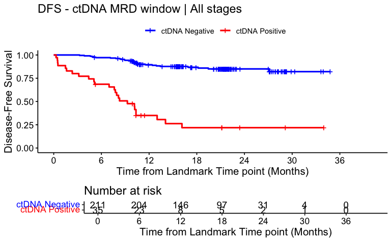

```r
surv_object <-Surv(time = circ_data$DFS.MRD.months, event = circ_data$DFS.Event)
KM_curve <- survfit(surv_object ~ ctDNA.MRD, data = circ_data,conf.int=0.95,conf.type="log-log")
ggsurvplot(KM_curve, data = circ_data, pval = FALSE, conf.int = FALSE, risk.table = TRUE, break.time.by=6, palette=c("blue","red"), title="DFS - ctDNA MRD window | All stages", ylab= "Disease-Free Survival", xlab="Time from Landmark Time point (Months)", legend.labs=c("ctDNA Negative", "ctDNA Positive"), legend.title="")
```

```r
summary(KM_curve, times= c(12, 18, 24))
```

```
Call: survfit(formula = surv_object ~ ctDNA.MRD, data = circ_data,
    conf.int = 0.95, conf.type = "log-log")

                ctDNA.MRD=NEGATIVE
 time n.risk n.event survival std.err lower 95% CI upper 95% CI
   12    146      21    0.895  0.0218        0.843        0.930
   18     97       4    0.868  0.0250        0.810        0.910
   24     31       2    0.850  0.0275        0.787        0.896

                ctDNA.MRD=POSITIVE
 time n.risk n.event survival std.err lower 95% CI upper 95% CI
   12      8      22    0.350  0.0830       0.1948        0.509
   18      5       3    0.219  0.0792       0.0884        0.386
   24      2       0    0.219  0.0792       0.0884        0.386
```

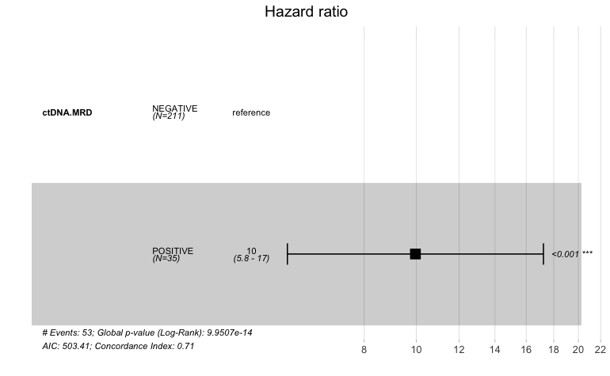

```r
circ_data$ctDNA.MRD <- factor(circ_data$ctDNA.MRD, levels=c("NEGATIVE","POSITIVE"))
cox_fit <- coxph(surv_object ~ ctDNA.MRD, data=circ_data)
ggforest(cox_fit,data = circ_data)
```

```r
summary(cox_fit)
```

```
Call:
coxph(formula = surv_object ~ ctDNA.MRD, data = circ_data)

  n= 246, number of events= 53

                    coef exp(coef) se(coef)     z Pr(>|z|)
ctDNA.MRDPOSITIVE 2.2985    9.9592   0.2795 8.222   <2e-16 ***
---
Signif. codes:  0 ‘***’ 0.001 ‘**’ 0.01 ‘*’ 0.05 ‘.’ 0.1 ‘ ’ 1

                  exp(coef) exp(-coef) lower .95 upper .95
ctDNA.MRDPOSITIVE     9.959     0.1004     5.758     17.23

Concordance= 0.709  (se = 0.032 )
Likelihood ratio test= 55.38  on 1 df,   p=1e-13
Wald test            = 67.61  on 1 df,   p=<2e-16
Score (logrank) test = 101.2  on 1 df,   p=<2e-16
```

```r
cox_fit_summary <- summary(cox_fit)

# Extract values for HR, 95% CI, and p-value
HR <- cox_fit_summary$coefficients[2]
lower_CI <- cox_fit_summary$conf.int[3]
upper_CI <- cox_fit_summary$conf.int[4]
p_value <- cox_fit_summary$coefficients[5]
label_text <- paste0("HR = ", round(HR, 2), " (", round(lower_CI, 2), "-", round(upper_CI, 2), "); p = ", round(p_value, 3))
print(label_text)
```

```
[1] "HR = 9.96 (5.76-17.23); p = 0"
```

```r
#Fisher test for DFS percentages at 12, 18, and 24 months
dfs_times <- c(12, 18, 24)
p_values <- sapply(dfs_times, function(time) {
  neg_count <- sum(circ_data$ctDNA.MRD == "NEGATIVE" & circ_data$DFS.MRD.months >= time & circ_data$DFS.Event == 0)
  pos_count <- sum(circ_data$ctDNA.MRD == "POSITIVE" & circ_data$DFS.MRD.months >= time & circ_data$DFS.Event == 0)
  neg_total <- sum(circ_data$ctDNA.MRD == "NEGATIVE")
  pos_total <- sum(circ_data$ctDNA.MRD == "POSITIVE")

  neg_surv <- neg_total - sum(circ_data$ctDNA.MRD == "NEGATIVE" & circ_data$DFS.Event == 1 & circ_data$DFS.MRD.months < time)
  pos_surv <- pos_total - sum(circ_data$ctDNA.MRD == "POSITIVE" & circ_data$DFS.Event == 1 & circ_data$DFS.MRD.months < time)

  surv_matrix <- matrix(c(neg_surv, pos_surv, neg_total - neg_surv, pos_total - pos_surv), nrow = 2)
  test_result <- fisher.test(surv_matrix)
  return(test_result$p.value)
})
names(p_values) <- paste0("p-value at ", dfs_times, " months")
print(p_values)
```

```
p-value at 12 months p-value at 18 months p-value at 24 months
        3.289740e-11         6.618049e-13         2.261958e-12
```

#Multivariate cox regression at MRD Window for DFS - All stages Landmark MRD timepoint

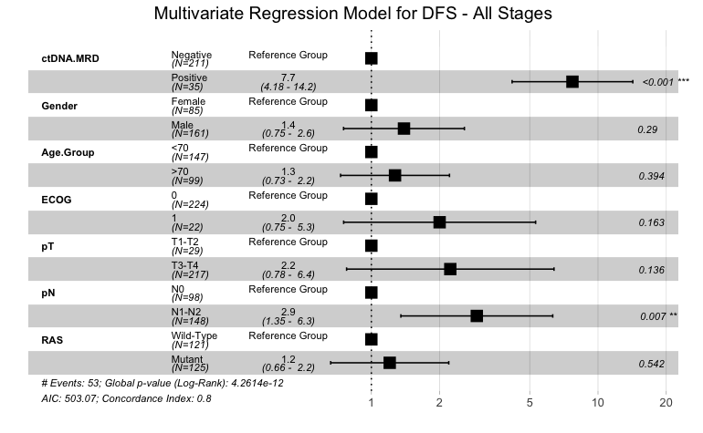

```r
rm(list=ls())
setwd("~/Downloads")
circ_data <- read.csv("Galaxy Data_20240603 Complete Dataset.csv")
circ_data <- circ_data[circ_data$CohortB=="TRUE",]
circ_data <- circ_data[circ_data$ctDNA.MRD!="",]
circ_data <- circ_data[circ_data$DFS.MRD.months>=0,]
circ_datadf <- as.data.frame(circ_data)

circ_data$ctDNA.MRD <- factor(circ_data$ctDNA.MRD, levels=c("NEGATIVE","POSITIVE"), labels = c("Negative", "Positive"))
circ_data$Gender <- factor(circ_data$Gender, levels = c("Female", "Male"))
circ_data$Age.Group <- factor(circ_data$Age.Group, levels = c("1", "2"), labels = c("<70", ">70"))
circ_data$ECOG <- factor(circ_data$ECOG, levels = c("0", "1"))
circ_data$pT <- factor(circ_data$pT, levels = c("T1-T2", "T3-T4"))
circ_data$pN <- factor(circ_data$pN, levels = c("N0", "N1-N2"))
circ_data$RAS <- factor(circ_data$RAS, levels = c("WT", "MUT"), labels = c("Wild-Type", "Mutant"))
surv_object <- Surv(time = circ_data$DFS.MRD.months, event = circ_data$DFS.Event)
cox_fit <- coxph(surv_object ~ ctDNA.MRD + Gender + Age.Group + ECOG + pT + pN + RAS, data=circ_data)
ggforest(cox_fit, data = circ_data, main = "Multivariate Regression Model for DFS - All Stages", refLabel = "Reference Group")
```

```r
test.ph <- cox.zph(cox_fit)
```

#DFS by ctDNA at the MRD Window - Stage II Landmark MRD timepoint

```r
rm(list=ls())
setwd("~/Downloads")
circ_data <- read.csv("Galaxy Data_20240603 Complete Dataset.csv")
circ_data <- circ_data[circ_data$CohortB=="TRUE",]
circ_data <- circ_data[circ_data$ctDNA.MRD!="",]
circ_data <- circ_data[!(circ_data$Stage %in% c("III")),]
circ_data <- circ_data[circ_data$DFS.MRD.months>=0,]
circ_datadf <- as.data.frame(circ_data)

survfit(Surv(time = circ_data$DFS.MRD.months, event = circ_data$DFS.Event)~ctDNA.MRD, data = circ_data)
```

```
Call: survfit(formula = Surv(time = circ_data$DFS.MRD.months, event = circ_data$DFS.Event) ~
    ctDNA.MRD, data = circ_data)

                    n events median 0.95LCL 0.95UCL
ctDNA.MRD=NEGATIVE 96      6     NA      NA      NA
ctDNA.MRD=POSITIVE  3      3     13   0.493      NA
```

```r
event_summary <- circ_data %>%
  group_by(ctDNA.MRD) %>%
  summarise(
    Total = n(),
    Events = sum(DFS.Event),
    Fraction = Events / n(),
    Percentage = (Events / n()) * 100
  )
print(event_summary)
```

| ctDNA.MRD | Total | Events | Fraction | Percentage |
| --- | --- | --- | --- | --- |
| NEGATIVE | 96 | 6 | 0.0625 | 6.25 |
| POSITIVE | 3 | 3 | 1.0000 | 100.00 |

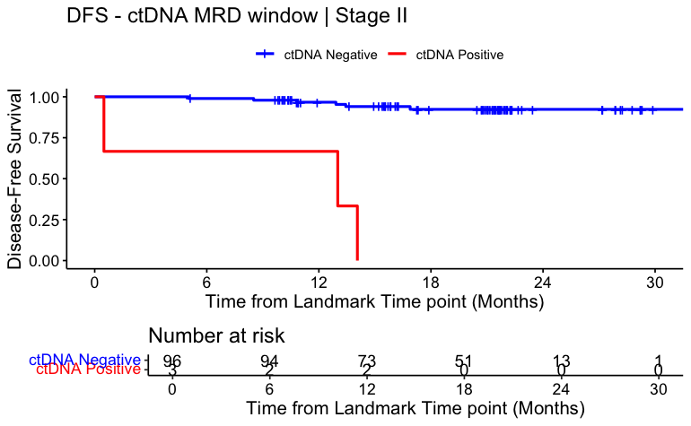

```r
surv_object <-Surv(time = circ_data$DFS.MRD.months, event = circ_data$DFS.Event)
KM_curve <- survfit(surv_object ~ ctDNA.MRD, data = circ_data,conf.int=0.95,conf.type="log-log")
ggsurvplot(KM_curve, data = circ_data, pval = FALSE, conf.int = FALSE, risk.table = TRUE, break.time.by=6, palette=c("blue","red"), title="DFS - ctDNA MRD window | Stage II", ylab= "Disease-Free Survival", xlab="Time from Landmark Time point (Months)", legend.labs=c("ctDNA Negative", "ctDNA Positive"), legend.title="")
```

```r
summary(KM_curve, times= c(12, 24))
```

```
Call: survfit(formula = surv_object ~ ctDNA.MRD, data = circ_data,
    conf.int = 0.95, conf.type = "log-log")

                ctDNA.MRD=NEGATIVE
 time n.risk n.event survival std.err lower 95% CI upper 95% CI
   12     73       3    0.967  0.0189        0.900        0.989
   24     13       3    0.923  0.0307        0.835        0.965

                ctDNA.MRD=POSITIVE
        time       n.risk      n.event     survival      std.err lower 95% CI upper 95% CI
     12.0000       2.0000       1.0000       0.6667       0.2722       0.0541       0.9452
```

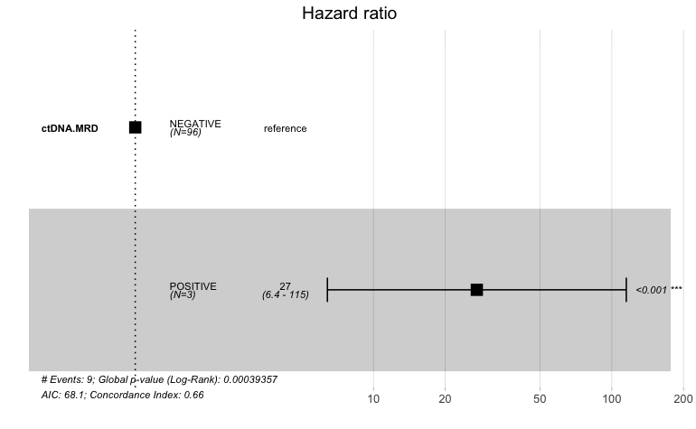

```r
circ_data$ctDNA.MRD <- factor(circ_data$ctDNA.MRD, levels=c("NEGATIVE","POSITIVE"))
cox_fit <- coxph(surv_object ~ ctDNA.MRD, data=circ_data)
ggforest(cox_fit,data = circ_data)
```

```r
summary(cox_fit)
```

```
Call:
coxph(formula = surv_object ~ ctDNA.MRD, data = circ_data)

  n= 99, number of events= 9

                     coef exp(coef) se(coef)    z Pr(>|z|)
ctDNA.MRDPOSITIVE  3.3011   27.1423   0.7369 4.48 7.46e-06 ***
---
Signif. codes:  0 ‘***’ 0.001 ‘**’ 0.01 ‘*’ 0.05 ‘.’ 0.1 ‘ ’ 1

                  exp(coef) exp(-coef) lower .95 upper .95
ctDNA.MRDPOSITIVE     27.14    0.03684     6.404       115

Concordance= 0.66  (se = 0.077 )
Likelihood ratio test= 12.56  on 1 df,   p=4e-04
Wald test            = 20.07  on 1 df,   p=7e-06
Score (logrank) test = 45.99  on 1 df,   p=1e-11
```

```r
cox_fit_summary <- summary(cox_fit)

# Extract values for HR, 95% CI, and p-value
HR <- cox_fit_summary$coefficients[2]
lower_CI <- cox_fit_summary$conf.int[3]
upper_CI <- cox_fit_summary$conf.int[4]
p_value <- cox_fit_summary$coefficients[5]
label_text <- paste0("HR = ", round(HR, 2), " (", round(lower_CI, 2), "-", round(upper_CI, 2), "); p = ", round(p_value, 3))
print(label_text)
```

```
[1] "HR = 27.14 (6.4-115.04); p = 0"
```

```r
#Fisher test for DFS percentages at 12 and 24 months
dfs_times <- c(12, 24)
p_values <- sapply(dfs_times, function(time) {
  neg_count <- sum(circ_data$ctDNA.MRD == "NEGATIVE" & circ_data$DFS.MRD.months >= time & circ_data$DFS.Event == 0)
  pos_count <- sum(circ_data$ctDNA.MRD == "POSITIVE" & circ_data$DFS.MRD.months >= time & circ_data$DFS.Event == 0)
  neg_total <- sum(circ_data$ctDNA.MRD == "NEGATIVE")
  pos_total <- sum(circ_data$ctDNA.MRD == "POSITIVE")

  neg_surv <- neg_total - sum(circ_data$ctDNA.MRD == "NEGATIVE" & circ_data$DFS.Event == 1 & circ_data$DFS.MRD.months < time)
  pos_surv <- pos_total - sum(circ_data$ctDNA.MRD == "POSITIVE" & circ_data$DFS.Event == 1 & circ_data$DFS.MRD.months < time)

  surv_matrix <- matrix(c(neg_surv, pos_surv, neg_total - neg_surv, pos_total - pos_surv), nrow = 2)
  test_result <- fisher.test(surv_matrix)
  return(test_result$p.value)
})
names(p_values) <- paste0("p-value at ", dfs_times, " months")
print(p_values)
```

```
p-value at 12 months p-value at 24 months
        0.1175270483         0.0005355469
```

```r
rm(list=ls())
setwd("~/Downloads")
circ_data <- read.csv("Galaxy Data_20240603 Complete Dataset.csv")
circ_data <- circ_data[circ_data$Eligible=="TRUE",]
circ_data <- circ_data[circ_data$ctDNA.MRD!="",]
circ_data <- circ_data[!(circ_data$Stage %in% c("II")),]
circ_data <- circ_data[circ_data$DFS.MRD.months>=0,]
circ_datadf <- as.data.frame(circ_data)

survfit(Surv(time = circ_data$DFS.MRD.months, event = circ_data$DFS.Event)~ctDNA.MRD, data = circ_data)
```

```
Call: survfit(formula = Surv(time = circ_data$DFS.MRD.months, event = circ_data$DFS.Event) ~
    ctDNA.MRD, data = circ_data)

   1 observation deleted due to missingness
                      n events median 0.95LCL 0.95UCL
ctDNA.MRD=NEGATIVE 1189    203     NA      NA      NA
ctDNA.MRD=POSITIVE  291    233   5.06     4.6    6.51
```

```r
event_summary <- circ_data %>%
  group_by(ctDNA.MRD) %>%
  summarise(
    Total = n(),
    Events = sum(DFS.Event),
    Fraction = Events / n(),
    Percentage = (Events / n()) * 100
  )
print(event_summary)
```

| ctDNA.MRD | Total | Events | Fraction | Percentage |
| --- | --- | --- | --- | --- |
| NEGATIVE | 1189 | 203 | 0.1707317 | 17.07317 |
| POSITIVE | 291 | 233 | 0.8006873 | 80.06873 |
| NA | 1 | NA | NA | NA |

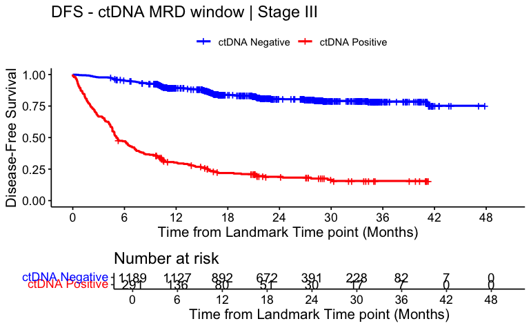

```r
surv_object <-Surv(time = circ_data$DFS.MRD.months, event = circ_data$DFS.Event)
KM_curve <- survfit(surv_object ~ ctDNA.MRD, data = circ_data,conf.int=0.95,conf.type="log-log")
ggsurvplot(KM_curve, data = circ_data, pval = FALSE, conf.int = FALSE, risk.table = TRUE, break.time.by=6, palette=c("blue","red"), title="DFS - ctDNA MRD window | Stage III", ylab= "Disease-Free Survival", xlab="Time from Landmark Time point (Months)", legend.labs=c("ctDNA Negative", "ctDNA Positive"), legend.title="")
```

```r
summary(KM_curve, times= c(24, 30))
```

```
Call: survfit(formula = surv_object ~ ctDNA.MRD, data = circ_data,
    conf.int = 0.95, conf.type = "log-log")

1 observation deleted due to missingness
                ctDNA.MRD=NEGATIVE
 time n.risk n.event survival std.err lower 95% CI upper 95% CI
   24    391     195    0.806  0.0130        0.779        0.830
   30    228       6    0.791  0.0141        0.762        0.817

                ctDNA.MRD=POSITIVE
 time n.risk n.event survival std.err lower 95% CI upper 95% CI
   24     30     229    0.189  0.0245        0.144        0.239
   30     17       3    0.166  0.0250        0.120        0.218
```

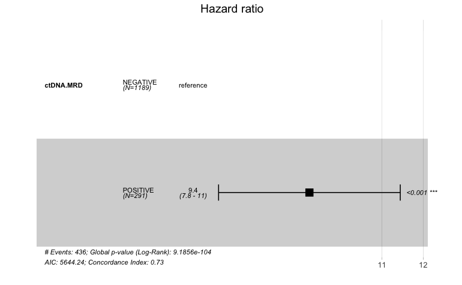

```r
circ_data$ctDNA.MRD <- factor(circ_data$ctDNA.MRD, levels=c("NEGATIVE","POSITIVE"))
cox_fit <- coxph(surv_object ~ ctDNA.MRD, data=circ_data)
ggforest(cox_fit,data = circ_data)
```

```r
summary(cox_fit)
```

```
Call:
coxph(formula = surv_object ~ ctDNA.MRD, data = circ_data)

  n= 1480, number of events= 436
   (1 observation deleted due to missingness)

                     coef exp(coef) se(coef)     z Pr(>|z|)
ctDNA.MRDPOSITIVE 2.24488   9.43924  0.09775 22.97   <2e-16 ***
---
Signif. codes:  0 ‘***’ 0.001 ‘**’ 0.01 ‘*’ 0.05 ‘.’ 0.1 ‘ ’ 1

                  exp(coef) exp(-coef) lower .95 upper .95
ctDNA.MRDPOSITIVE     9.439     0.1059     7.794     11.43

Concordance= 0.729  (se = 0.011 )
Likelihood ratio test= 467.9  on 1 df,   p=<2e-16
Wald test            = 527.5  on 1 df,   p=<2e-16
Score (logrank) test = 768.2  on 1 df,   p=<2e-16
```

```r
cox_fit_summary <- summary(cox_fit)

# Extract values for HR, 95% CI, and p-value
HR <- cox_fit_summary$coefficients[2]
lower_CI <- cox_fit_summary$conf.int[3]
upper_CI <- cox_fit_summary$conf.int[4]
p_value <- cox_fit_summary$coefficients[5]
label_text <- paste0("HR = ", round(HR, 2), " (", round(lower_CI, 2), "-", round(upper_CI, 2), "); p = ", round(p_value, 3))
print(label_text)
```

```
[1] "HR = 9.44 (7.79-11.43); p = 0"
```

```r
#Fisher test for DFS percentages at 24 and 30 months
dfs_times <- c(24, 30)
circ_data <- na.omit(circ_data[, c("ctDNA.MRD", "DFS.MRD.months", "DFS.Event")])
p_values <- sapply(dfs_times, function(time) {
  neg_count <- sum(circ_data$ctDNA.MRD == "NEGATIVE" & circ_data$DFS.MRD.months >= time & circ_data$DFS.Event == 0)
  pos_count <- sum(circ_data$ctDNA.MRD == "POSITIVE" & circ_data$DFS.MRD.months >= time & circ_data$DFS.Event == 0)
  neg_total <- sum(circ_data$ctDNA.MRD == "NEGATIVE")
  pos_total <- sum(circ_data$ctDNA.MRD == "POSITIVE")

  neg_surv <- neg_total - sum(circ_data$ctDNA.MRD == "NEGATIVE" & circ_data$DFS.Event == 1 & circ_data$DFS.MRD.months < time)
  pos_surv <- pos_total - sum(circ_data$ctDNA.MRD == "POSITIVE" & circ_data$DFS.Event == 1 & circ_data$DFS.MRD.months < time)

  surv_matrix <- matrix(c(neg_surv, pos_surv, neg_total - neg_surv, pos_total - pos_surv), nrow = 2)
  test_result <- fisher.test(surv_matrix)
  return(test_result$p.value)
})
names(p_values) <- paste0("p-value at ", dfs_times, " months")
print(p_values)
```

```
p-value at 24 months p-value at 30 months
        6.506858e-91         5.794183e-92
```

#DFS by ACT treatment in MRD negative - Stage II/III

```r
rm(list=ls())
setwd("~/Downloads")
circ_data <- read.csv("Galaxy Data_20240603 Complete Dataset.csv")
circ_data <- circ_data[circ_data$CohortB=="TRUE",]
circ_data <- circ_data[circ_data$ctDNA.MRD!="",]
circ_data <- circ_data[circ_data$ctDNA.MRD=="NEGATIVE",]
circ_data$DFS.months=circ_data$DFS.months-2
circ_data <- circ_data[circ_data$DFS.months>=0,]
circ_datadf <- as.data.frame(circ_data)

survfit(Surv(time = circ_data$DFS.months, event = circ_data$DFS.Event)~ACT, data = circ_data)
```

```
Call: survfit(formula = Surv(time = circ_data$DFS.months, event = circ_data$DFS.Event) ~
    ACT, data = circ_data)

            n events median 0.95LCL 0.95UCL
ACT=FALSE 115     16     NA      NA      NA
ACT=TRUE   96     12     NA      NA      NA
```

```r
event_summary <- circ_data %>%
  group_by(ACT) %>%
  summarise(
    Total = n(),
    Events = sum(DFS.Event),
    Fraction = Events / n(),
    Percentage = (Events / n()) * 100
  )
print(event_summary)
```

| ACT | Total | Events | Fraction | Percentage |
| --- | --- | --- | --- | --- |
| FALSE | 115 | 16 | 0.1391304 | 13.91304 |
| TRUE | 96 | 12 | 0.1250000 | 12.50000 |

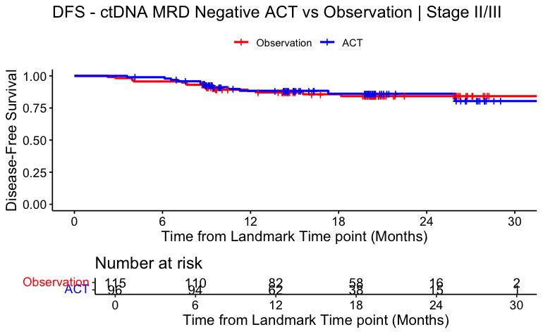

```r
surv_object <-Surv(time = circ_data$DFS.months, event = circ_data$DFS.Event)
KM_curve <- survfit(surv_object ~ ACT, data = circ_data,conf.int=0.95,conf.type="log-log")
ggsurvplot(KM_curve, data = circ_data, pval = FALSE, conf.int = FALSE, risk.table = TRUE, break.time.by=6, palette=c("red","blue"), title="DFS - ctDNA MRD Negative ACT vs Observation | Stage II/III", ylab= "Disease-Free Survival", xlab="Time from Landmark Time point (Months)", legend.labs=c("Observation", "ACT"), legend.title="")
```

```r
summary(KM_curve, times= c(24))
```

```
Call: survfit(formula = surv_object ~ ACT, data = circ_data, conf.int = 0.95,
    conf.type = "log-log")

                ACT=FALSE
        time       n.risk      n.event     survival      std.err lower 95% CI upper 95% CI
     24.0000      16.0000      16.0000       0.8419       0.0373       0.7521       0.9013

                ACT=TRUE
        time       n.risk      n.event     survival      std.err lower 95% CI upper 95% CI
     24.0000      15.0000      11.0000       0.8612       0.0407       0.7574       0.9228
```

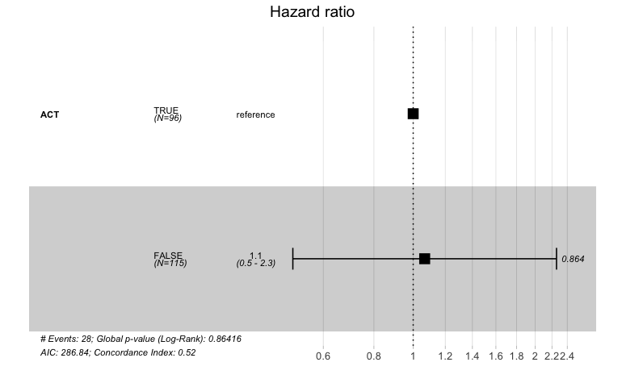

```r
circ_data$ACT <- factor(circ_data$ACT, levels=c("TRUE","FALSE"))
cox_fit <- coxph(surv_object ~ ACT, data=circ_data)
ggforest(cox_fit,data = circ_data)
```

```r
summary(cox_fit)
```

```
Call:
coxph(formula = surv_object ~ ACT, data = circ_data)

  n= 211, number of events= 28

            coef exp(coef) se(coef)     z Pr(>|z|)
ACTFALSE 0.06529   1.06747  0.38220 0.171    0.864

         exp(coef) exp(-coef) lower .95 upper .95
ACTFALSE     1.067     0.9368    0.5047     2.258

Concordance= 0.517  (se = 0.048 )
Likelihood ratio test= 0.03  on 1 df,   p=0.9
Wald test            = 0.03  on 1 df,   p=0.9
Score (logrank) test = 0.03  on 1 df,   p=0.9
```

```r
cox_fit_summary <- summary(cox_fit)

# Extract values for HR, 95% CI, and p-value
HR <- cox_fit_summary$coefficients[2]
lower_CI <- cox_fit_summary$conf.int[3]
upper_CI <- cox_fit_summary$conf.int[4]
p_value <- cox_fit_summary$coefficients[5]
label_text <- paste0("HR = ", round(HR, 2), " (", round(lower_CI, 2), "-", round(upper_CI, 2), "); p = ", round(p_value, 3))
print(label_text)
```

```
[1] "HR = 1.07 (0.5-2.26); p = 0.864"
```

```r
#Fisher test for DFS percentages at 24
dfs_times <- c(24)
p_values <- sapply(dfs_times, function(time) {
  neg_count <- sum(circ_data$ACT == "TRUE" & circ_data$DFS.months >= time & circ_data$DFS.Event == 0)
  pos_count <- sum(circ_data$ACT == "FALSE" & circ_data$DFS.months >= time & circ_data$DFS.Event == 0)
  neg_total <- sum(circ_data$ACT == "TRUE")
  pos_total <- sum(circ_data$ACT == "FALSE")

  neg_surv <- neg_total - sum(circ_data$ACT == "TRUE" & circ_data$DFS.Event == 1 & circ_data$DFS.months < time)
  pos_surv <- pos_total - sum(circ_data$ACT == "FALSE" & circ_data$DFS.Event == 1 & circ_data$DFS.months < time)

  surv_matrix <- matrix(c(neg_surv, pos_surv, neg_total - neg_surv, pos_total - pos_surv), nrow = 2)
  test_result <- fisher.test(surv_matrix)
  return(test_result$p.value)
})
names(p_values) <- paste0("p-value at ", dfs_times, " months")
print(p_values)
```

```
p-value at 24 months
           0.6811626
```

```r
#Adjusted HR "ACT vs no ACT" - Non ACT as reference
rm(list=ls())
setwd("~/Downloads")
circ_data <- read.csv("Galaxy Data_20240603 Complete Dataset.csv")
circ_data <- circ_data[circ_data$CohortB=="TRUE",]
circ_data <- circ_data[circ_data$ctDNA.MRD!="",]
circ_data <- circ_data[circ_data$ctDNA.MRD=="NEGATIVE",]
circ_data$DFS.months=circ_data$DFS.months-2
circ_data <- circ_data[circ_data$DFS.months>=0,]
circ_datadf <- as.data.frame(circ_data)

circ_data$ACT <- factor(circ_data$ACT, levels=c("FALSE","TRUE"))
circ_data$Age.Group <- factor(circ_data$Age.Group, levels = c("1", "2"), labels = c("<70", "≥70"))
circ_data$Gender <- factor(circ_data$Gender, levels = c("Female", "Male"))
circ_data$Stage <- factor(circ_data$Stage, levels = c("II", "III"))
circ_data$ECOG <- factor(circ_data$ECOG, levels=c("0","1"))
surv_object <- Surv(time = circ_data$DFS.months, event = circ_data$DFS.Event)
cox_fit <- coxph(surv_object ~ ACT + Gender + Age.Group + Stage + ECOG, data=circ_data)
summary(cox_fit)
```

```
Call:
coxph(formula = surv_object ~ ACT + Gender + Age.Group + Stage +
    ECOG, data = circ_data)

  n= 211, number of events= 28

                coef exp(coef) se(coef)      z Pr(>|z|)
ACTTRUE      -0.5269    0.5904   0.4211 -1.251  0.21080
GenderMale    0.1145    1.1213   0.4081  0.280  0.77910
Age.Group≥70  0.3280    1.3883   0.4022  0.816  0.41472
StageIII      1.5211    4.5774   0.4886  3.113  0.00185 **
ECOG1         0.5215    1.6846   0.5509  0.947  0.34383
---
Signif. codes:  0 ‘***’ 0.001 ‘**’ 0.01 ‘*’ 0.05 ‘.’ 0.1 ‘ ’ 1

             exp(coef) exp(-coef) lower .95 upper .95
ACTTRUE         0.5904     1.6937    0.2587     1.348
GenderMale      1.1213     0.8918    0.5039     2.495
Age.Group≥70    1.3883     0.7203    0.6311     3.054
StageIII        4.5774     0.2185    1.7569    11.926
ECOG1           1.6846     0.5936    0.5722     4.960

Concordance= 0.71  (se = 0.043 )
Likelihood ratio test= 12.82  on 5 df,   p=0.03
Wald test            = 11.73  on 5 df,   p=0.04
Score (logrank) test = 12.73  on 5 df,   p=0.03
```

#DFS by ACT treatment in MRD positive - Stage II/III

```r
rm(list=ls())
setwd("~/Downloads")
circ_data <- read.csv("Galaxy Data_20240603 Complete Dataset.csv")
circ_data <- circ_data[circ_data$CohortB=="TRUE",]
circ_data <- circ_data[circ_data$ctDNA.MRD!="",]
circ_data <- circ_data[circ_data$ctDNA.MRD=="POSITIVE",]
circ_data$DFS.months=circ_data$DFS.months-2
circ_data <- circ_data[circ_data$DFS.months>=0,]
circ_datadf <- as.data.frame(circ_data)

survfit(Surv(time = circ_data$DFS.months, event = circ_data$DFS.Event)~ACT, data = circ_data)
```

```
Call: survfit(formula = Surv(time = circ_data$DFS.months, event = circ_data$DFS.Event) ~
    ACT, data = circ_data)

           n events median 0.95LCL 0.95UCL
ACT=FALSE  6      5   5.62    1.22      NA
ACT=TRUE  25     16   9.33    6.97      NA
```

```r
event_summary <- circ_data %>%
  group_by(ACT) %>%
  summarise(
    Total = n(),
    Events = sum(DFS.Event),
    Fraction = Events / n(),
    Percentage = (Events / n()) * 100
  )
print(event_summary)
```

| ACT | Total | Events | Fraction | Percentage |
| --- | --- | --- | --- | --- |
| FALSE | 6 | 5 | 0.8333333 | 83.33333 |
| TRUE | 25 | 16 | 0.6400000 | 64.00000 |

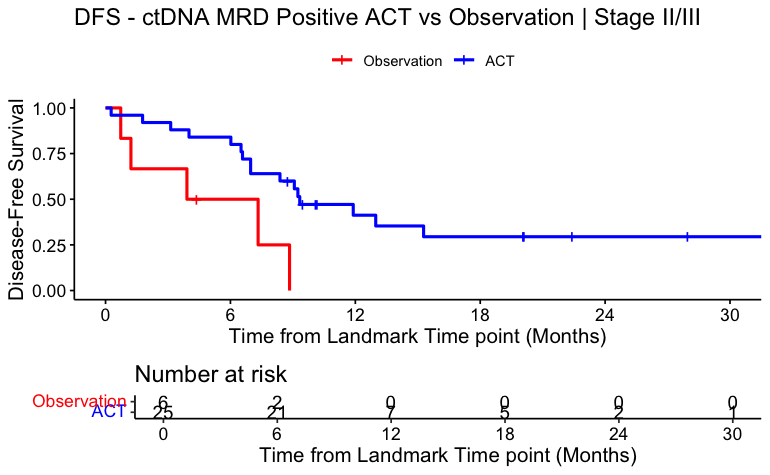

```r
surv_object <-Surv(time = circ_data$DFS.months, event = circ_data$DFS.Event)
KM_curve <- survfit(surv_object ~ ACT, data = circ_data,conf.int=0.95,conf.type="log-log")
ggsurvplot(KM_curve, data = circ_data, pval = FALSE, conf.int = FALSE, risk.table = TRUE, break.time.by=6, palette=c("red","blue"), title="DFS - ctDNA MRD Positive ACT vs Observation | Stage II/III", ylab= "Disease-Free Survival", xlab="Time from Landmark Time point (Months)", legend.labs=c("Observation", "ACT"), legend.title="")
```

```r
summary(KM_curve, times= c(6, 24))
```

```
Call: survfit(formula = surv_object ~ ACT, data = circ_data, conf.int = 0.95,
    conf.type = "log-log")

                ACT=FALSE
        time       n.risk      n.event     survival      std.err lower 95% CI upper 95% CI
       6.000        2.000        3.000        0.500        0.204        0.111        0.804

                ACT=TRUE
 time n.risk n.event survival std.err lower 95% CI upper 95% CI
    6     21       4    0.840  0.0733        0.628        0.937
   24      2      12    0.295  0.1026        0.118        0.497
```

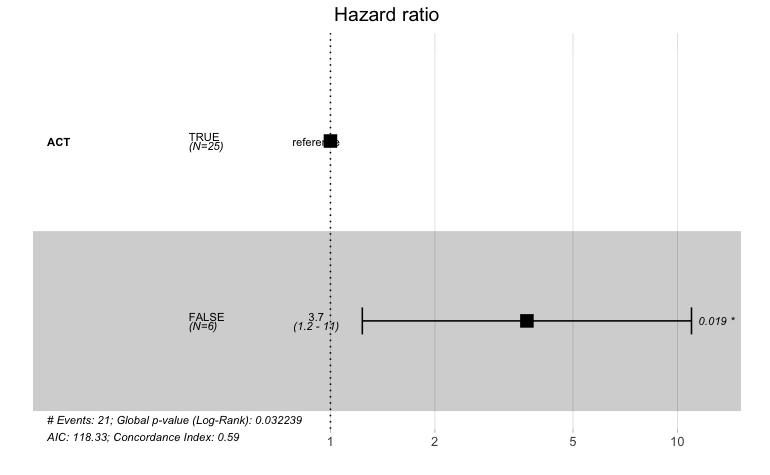

```r
circ_data$ACT <- factor(circ_data$ACT, levels=c("TRUE","FALSE"))
cox_fit <- coxph(surv_object ~ ACT, data=circ_data)
ggforest(cox_fit,data = circ_data)
```

```r
summary(cox_fit)
```

```
Call:
coxph(formula = surv_object ~ ACT, data = circ_data)

  n= 31, number of events= 21

           coef exp(coef) se(coef)     z Pr(>|z|)
ACTFALSE 1.3036    3.6825   0.5572 2.339   0.0193 *
---
Signif. codes:  0 ‘***’ 0.001 ‘**’ 0.01 ‘*’ 0.05 ‘.’ 0.1 ‘ ’ 1

         exp(coef) exp(-coef) lower .95 upper .95
ACTFALSE     3.682     0.2716     1.235     10.98

Concordance= 0.593  (se = 0.045 )
Likelihood ratio test= 4.59  on 1 df,   p=0.03
Wald test            = 5.47  on 1 df,   p=0.02
Score (logrank) test = 6.25  on 1 df,   p=0.01
```

```r
cox_fit_summary <- summary(cox_fit)

# Extract values for HR, 95% CI, and p-value
HR <- cox_fit_summary$coefficients[2]
lower_CI <- cox_fit_summary$conf.int[3]
upper_CI <- cox_fit_summary$conf.int[4]
p_value <- cox_fit_summary$coefficients[5]
label_text <- paste0("HR = ", round(HR, 2), " (", round(lower_CI, 2), "-", round(upper_CI, 2), "); p = ", round(p_value, 3))
print(label_text)
```

```
[1] "HR = 3.68 (1.24-10.98); p = 0.019"
```

```r
#Adjusted HR "ACT vs no ACT" - Non ACT as reference
rm(list=ls())
setwd("~/Downloads")
circ_data <- read.csv("Galaxy Data_20240603 Complete Dataset.csv")
circ_data <- circ_data[circ_data$CohortB=="TRUE",]
circ_data <- circ_data[circ_data$ctDNA.MRD!="",]
circ_data <- circ_data[circ_data$ctDNA.MRD=="POSITIVE",]
circ_data$DFS.months=circ_data$DFS.months-2
circ_data <- circ_data[circ_data$DFS.months>=0,]
circ_datadf <- as.data.frame(circ_data)

circ_data$ACT <- factor(circ_data$ACT, levels=c("FALSE","TRUE"))
circ_data$Age.Group <- factor(circ_data$Age.Group, levels = c("1", "2"), labels = c("<70", "≥70"))
circ_data$Gender <- factor(circ_data$Gender, levels = c("Female", "Male"))
circ_data$Stage <- factor(circ_data$Stage, levels = c("II", "III"))
circ_data$ECOG <- factor(circ_data$ECOG, levels=c("0","1"))
surv_object <- Surv(time = circ_data$DFS.months, event = circ_data$DFS.Event)
cox_fit <- coxph(surv_object ~ ACT + Gender + Age.Group + Stage + ECOG, data=circ_data)
summary(cox_fit)
```

```
Call:
coxph(formula = surv_object ~ ACT + Gender + Age.Group + Stage +
    ECOG, data = circ_data)

  n= 31, number of events= 21

                 coef exp(coef) se(coef)      z Pr(>|z|)
ACTTRUE      -1.27835   0.27850  0.59142 -2.162   0.0307 *
GenderMale    0.35495   1.42611  0.51244  0.693   0.4885
Age.Group≥70  0.12911   1.13782  0.45951  0.281   0.7787
StageIII      0.08804   1.09203  0.81274  0.108   0.9137
ECOG1         1.40597   4.07950  1.13540  1.238   0.2156
---
Signif. codes:  0 ‘***’ 0.001 ‘**’ 0.01 ‘*’ 0.05 ‘.’ 0.1 ‘ ’ 1

             exp(coef) exp(-coef) lower .95 upper .95
ACTTRUE         0.2785     3.5907   0.08738    0.8876
GenderMale      1.4261     0.7012   0.52236    3.8935
Age.Group≥70    1.1378     0.8789   0.46231    2.8003
StageIII        1.0920     0.9157   0.22204    5.3708
ECOG1           4.0795     0.2451   0.44071   37.7622

Concordance= 0.632  (se = 0.066 )
Likelihood ratio test= 6.01  on 5 df,   p=0.3
Wald test            = 6.81  on 5 df,   p=0.2
Score (logrank) test = 7.76  on 5 df,   p=0.2
```

#DFS by ctDNA at 3 months - All stages Landmark 3 months timepoint

```r
rm(list=ls())
setwd("~/Downloads")
circ_data <- read.csv("Galaxy Data_20240603 Complete Dataset.csv")
circ_data <- circ_data[circ_data$CohortB=="TRUE",]
circ_data <- circ_data[circ_data$ctDNA.3months!="",]
circ_data <- circ_data[circ_data$DFS.3mo.months>=0,]
circ_datadf <- as.data.frame(circ_data)

survfit(Surv(time = circ_data$DFS.3mo.months, event = circ_data$DFS.Event)~ctDNA.3months, data = circ_data)
```

```
Call: survfit(formula = Surv(time = circ_data$DFS.3mo.months, event = circ_data$DFS.Event) ~
    ctDNA.3months, data = circ_data)

                         n events median 0.95LCL 0.95UCL
ctDNA.3months=NEGATIVE 204     31     NA      NA      NA
ctDNA.3months=POSITIVE  19     14   8.28    5.59      NA
```

```r
event_summary <- circ_data %>%
  group_by(ctDNA.3months) %>%
  summarise(
    Total = n(),
    Events = sum(DFS.Event),
    Fraction = Events / n(),
    Percentage = (Events / n()) * 100
  )
print(event_summary)
```

| ctDNA.3months | Total | Events | Fraction | Percentage |
| --- | --- | --- | --- | --- |
| NEGATIVE | 204 | 31 | 0.1519608 | 15.19608 |
| POSITIVE | 19 | 14 | 0.7368421 | 73.68421 |

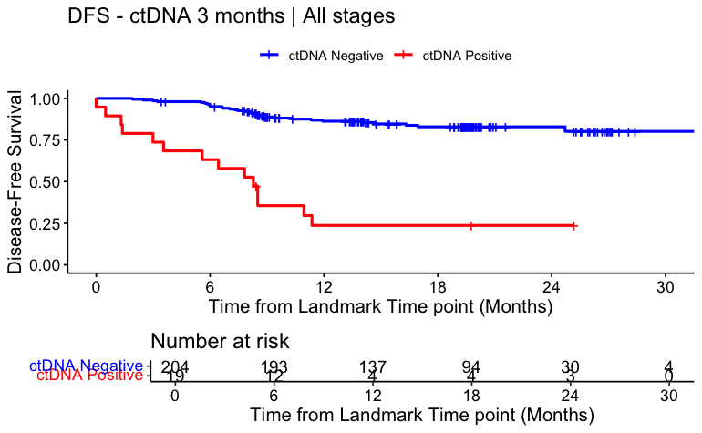

```r
surv_object <-Surv(time = circ_data$DFS.3mo.months, event = circ_data$DFS.Event)
KM_curve <- survfit(surv_object ~ ctDNA.3months, data = circ_data,conf.int=0.95,conf.type="log-log")
ggsurvplot(KM_curve, data = circ_data, pval = FALSE, conf.int = FALSE, risk.table = TRUE, break.time.by=6, palette=c("blue","red"), title="DFS - ctDNA 3 months | All stages", ylab= "Disease-Free Survival", xlab="Time from Landmark Time point (Months)", legend.labs=c("ctDNA Negative", "ctDNA Positive"), legend.title="")
```

```r
summary(KM_curve, times= c(12, 24))
```

```
Call: survfit(formula = surv_object ~ ctDNA.3months, data = circ_data,
    conf.int = 0.95, conf.type = "log-log")

                ctDNA.3months=NEGATIVE
 time n.risk n.event survival std.err lower 95% CI upper 95% CI
   12    137      26    0.863  0.0252        0.805        0.905
   24     30       4    0.829  0.0293        0.762        0.879

                ctDNA.3months=POSITIVE
 time n.risk n.event survival std.err lower 95% CI upper 95% CI
   12      4      14    0.237   0.101       0.0758        0.447
   24      3       0    0.237   0.101       0.0758        0.447
```

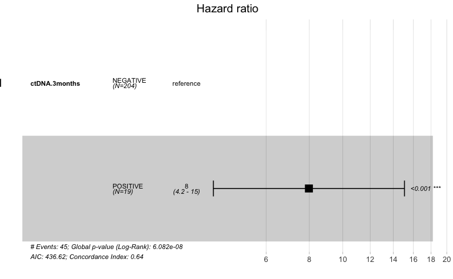

```r
circ_data$ctDNA.3months <- factor(circ_data$ctDNA.3months, levels=c("NEGATIVE","POSITIVE"))
cox_fit <- coxph(surv_object ~ ctDNA.3months, data=circ_data)
ggforest(cox_fit,data = circ_data)
```

```r
summary(cox_fit)
```

```
Call:
coxph(formula = surv_object ~ ctDNA.3months, data = circ_data)

  n= 223, number of events= 45

                        coef exp(coef) se(coef)     z Pr(>|z|)
ctDNA.3monthsPOSITIVE 2.0768    7.9792   0.3247 6.397 1.58e-10 ***
---
Signif. codes:  0 ‘***’ 0.001 ‘**’ 0.01 ‘*’ 0.05 ‘.’ 0.1 ‘ ’ 1

                      exp(coef) exp(-coef) lower .95 upper .95
ctDNA.3monthsPOSITIVE     7.979     0.1253     4.223     15.08

Concordance= 0.641  (se = 0.034 )
Likelihood ratio test= 29.34  on 1 df,   p=6e-08
Wald test            = 40.92  on 1 df,   p=2e-10
Score (logrank) test = 57.62  on 1 df,   p=3e-14
```

```r
cox_fit_summary <- summary(cox_fit)

# Extract values for HR, 95% CI, and p-value
HR <- cox_fit_summary$coefficients[2]
lower_CI <- cox_fit_summary$conf.int[3]
upper_CI <- cox_fit_summary$conf.int[4]
p_value <- cox_fit_summary$coefficients[5]
label_text <- paste0("HR = ", round(HR, 2), " (", round(lower_CI, 2), "-", round(upper_CI, 2), "); p = ", round(p_value, 3))
print(label_text)
```

```
[1] "HR = 7.98 (4.22-15.08); p = 0"
```

```r
#Fisher test for DFS percentages at 12 and 24 months
dfs_times <- c(12, 24)
p_values <- sapply(dfs_times, function(time) {
  neg_count <- sum(circ_data$ctDNA.3months == "NEGATIVE" & circ_data$DFS.3mo.months >= time & circ_data$DFS.Event == 0)
  pos_count <- sum(circ_data$ctDNA.3months == "POSITIVE" & circ_data$DFS.3mo.months >= time & circ_data$DFS.Event == 0)
  neg_total <- sum(circ_data$ctDNA.3months == "NEGATIVE")
  pos_total <- sum(circ_data$ctDNA.3months == "POSITIVE")

  neg_surv <- neg_total - sum(circ_data$ctDNA.3months == "NEGATIVE" & circ_data$DFS.Event == 1 & circ_data$DFS.3mo.months < time)
  pos_surv <- pos_total - sum(circ_data$ctDNA.3months == "POSITIVE" & circ_data$DFS.Event == 1 & circ_data$DFS.3mo.months < time)

  surv_matrix <- matrix(c(neg_surv, pos_surv, neg_total - neg_surv, pos_total - pos_surv), nrow = 2)
  test_result <- fisher.test(surv_matrix)
  return(test_result$p.value)
})
names(p_values) <- paste0("p-value at ", dfs_times, " months")
print(p_values)
```

```
p-value at 12 months p-value at 24 months
        2.546518e-08         1.138180e-07
```

#DFS by ctDNA at 6 months - All stages Landmark 6 months timepoint

```r
rm(list=ls())
setwd("~/Downloads")
circ_data <- read.csv("Galaxy Data_20240603 Complete Dataset.csv")
circ_data <- circ_data[circ_data$CohortB=="TRUE",]
circ_data <- circ_data[circ_data$ctDNA.6months!="",]
circ_data <- circ_data[circ_data$DFS.6mo.months>=0,]
circ_datadf <- as.data.frame(circ_data)

survfit(Surv(time = circ_data$DFS.6mo.months, event = circ_data$DFS.Event)~ctDNA.6months, data = circ_data)
```

```
Call: survfit(formula = Surv(time = circ_data$DFS.6mo.months, event = circ_data$DFS.Event) ~
    ctDNA.6months, data = circ_data)

                         n events median 0.95LCL 0.95UCL
ctDNA.6months=NEGATIVE 173     21     NA      NA      NA
ctDNA.6months=POSITIVE   9      7   3.68     2.6      NA
```

```r
event_summary <- circ_data %>%
  group_by(ctDNA.6months) %>%
  summarise(
    Total = n(),
    Events = sum(DFS.Event),
    Fraction = Events / n(),
    Percentage = (Events / n()) * 100
  )
print(event_summary)
```

| ctDNA.6months | Total | Events | Fraction | Percentage |
| --- | --- | --- | --- | --- |
| NEGATIVE | 173 | 21 | 0.1213873 | 12.13873 |
| POSITIVE | 9 | 7 | 0.7777778 | 77.77778 |

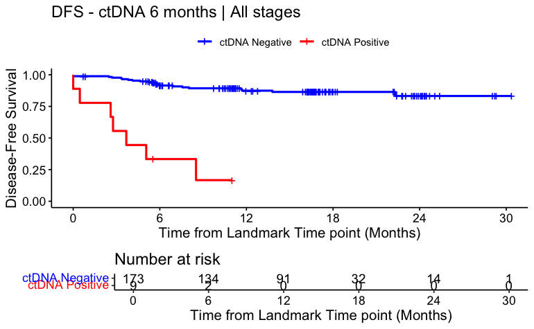

```r
surv_object <-Surv(time = circ_data$DFS.6mo.months, event = circ_data$DFS.Event)
KM_curve <- survfit(surv_object ~ ctDNA.6months, data = circ_data,conf.int=0.95,conf.type="log-log")
ggsurvplot(KM_curve, data = circ_data, pval = FALSE, conf.int = FALSE, risk.table = TRUE, break.time.by=6, palette=c("blue","red"), title="DFS - ctDNA 6 months | All stages", ylab= "Disease-Free Survival", xlab="Time from Landmark Time point (Months)", legend.labs=c("ctDNA Negative", "ctDNA Positive"), legend.title="")
```

```r
summary(KM_curve, times= c(6, 24))
```

```
Call: survfit(formula = surv_object ~ ctDNA.6months, data = circ_data,
    conf.int = 0.95, conf.type = "log-log")

                ctDNA.6months=NEGATIVE
 time n.risk n.event survival std.err lower 95% CI upper 95% CI
    6    134      14    0.915  0.0217        0.861        0.949
   24     14       7    0.832  0.0420        0.730        0.898

                ctDNA.6months=POSITIVE
        time       n.risk      n.event     survival      std.err lower 95% CI upper 95% CI
      6.0000       2.0000       6.0000       0.3333       0.1571       0.0783       0.6226
```

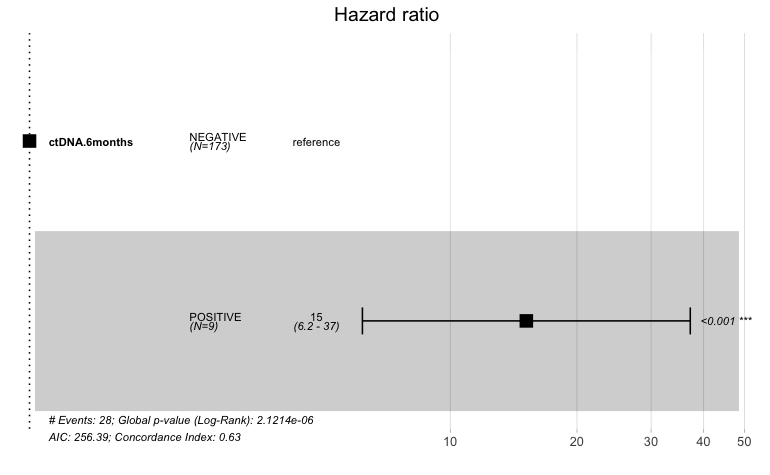

```r
circ_data$ctDNA.6months <- factor(circ_data$ctDNA.6months, levels=c("NEGATIVE","POSITIVE"))
cox_fit <- coxph(surv_object ~ ctDNA.6months, data=circ_data)
ggforest(cox_fit,data = circ_data)
```

```r
summary(cox_fit)
```

```
Call:
coxph(formula = surv_object ~ ctDNA.6months, data = circ_data)

  n= 182, number of events= 28

                         coef exp(coef) se(coef)    z Pr(>|z|)
ctDNA.6monthsPOSITIVE  2.7187   15.1598   0.4577 5.94 2.85e-09 ***
---
Signif. codes:  0 ‘***’ 0.001 ‘**’ 0.01 ‘*’ 0.05 ‘.’ 0.1 ‘ ’ 1

                      exp(coef) exp(-coef) lower .95 upper .95
ctDNA.6monthsPOSITIVE     15.16    0.06596     6.182     37.18

Concordance= 0.628  (se = 0.042 )
Likelihood ratio test= 22.48  on 1 df,   p=2e-06
Wald test            = 35.29  on 1 df,   p=3e-09
Score (logrank) test = 62.3  on 1 df,   p=3e-15
```

```r
cox_fit_summary <- summary(cox_fit)

# Extract values for HR, 95% CI, and p-value
HR <- cox_fit_summary$coefficients[2]
lower_CI <- cox_fit_summary$conf.int[3]
upper_CI <- cox_fit_summary$conf.int[4]
p_value <- cox_fit_summary$coefficients[5]
label_text <- paste0("HR = ", round(HR, 2), " (", round(lower_CI, 2), "-", round(upper_CI, 2), "); p = ", round(p_value, 3))
print(label_text)
```

```
[1] "HR = 15.16 (6.18-37.18); p = 0"
```

```r
#Fisher test for DFS percentages at 6 and 24 months
dfs_times <- c(6, 24)
p_values <- sapply(dfs_times, function(time) {
  neg_count <- sum(circ_data$ctDNA.6months == "NEGATIVE" & circ_data$DFS.6mo.months >= time & circ_data$DFS.Event == 0)
  pos_count <- sum(circ_data$ctDNA.6months == "POSITIVE" & circ_data$DFS.6mo.months >= time & circ_data$DFS.Event == 0)
  neg_total <- sum(circ_data$ctDNA.6months == "NEGATIVE")
  pos_total <- sum(circ_data$ctDNA.6months == "POSITIVE")

  neg_surv <- neg_total - sum(circ_data$ctDNA.6months == "NEGATIVE" & circ_data$DFS.Event == 1 & circ_data$DFS.6mo.months < time)
  pos_surv <- pos_total - sum(circ_data$ctDNA.6months == "POSITIVE" & circ_data$DFS.Event == 1 & circ_data$DFS.6mo.months < time)

  surv_matrix <- matrix(c(neg_surv, pos_surv, neg_total - neg_surv, pos_total - pos_surv), nrow = 2)
  test_result <- fisher.test(surv_matrix)
  return(test_result$p.value)
})
names(p_values) <- paste0("p-value at ", dfs_times, " months")
print(p_values)
```

```
 p-value at 6 months p-value at 24 months
        5.667547e-05         2.922826e-05
```

#DFS by ctDNA Clearance ACT-treated at 3 months - all stages

```r
rm(list=ls())
setwd("~/Downloads")
circ_data <- read.csv("Galaxy Data_20240603 Complete Dataset.csv")
circ_data <- circ_data[circ_data$CohortB=="TRUE",]
circ_data <- circ_data[circ_data$ctDNA.MRD!="",]
circ_data <- circ_data[circ_data$ACT==TRUE,]
circ_datadf <- as.data.frame(circ_data)

circ_data$ctDNA.Dynamics <- NA #first we create the variable for the ctDNA & NAC combination, and we assign values
circ_data <- circ_data %>%
  mutate(ctDNA.Dynamics = case_when(
    ctDNA.MRD == "POSITIVE" & ctDNA.3months == "NEGATIVE" ~ 1,
    ctDNA.MRD == "POSITIVE" & ctDNA.3months == "POSITIVE" ~ 2
  ))

circ_data <- circ_data[circ_data$DFS.3mo.months>=0,]
survfit(Surv(time = circ_data$DFS.3mo.months, event = circ_data$DFS.Event)~ctDNA.Dynamics, data = circ_data)
```

```
Call: survfit(formula = Surv(time = circ_data$DFS.3mo.months, event = circ_data$DFS.Event) ~
    ctDNA.Dynamics, data = circ_data)

   97 observations deleted due to missingness
                  n events median 0.95LCL 0.95UCL
ctDNA.Dynamics=1 16      8  14.16    6.01      NA
ctDNA.Dynamics=2  8      7   8.05    5.59      NA
```

```r
event_summary <- circ_data %>%
  group_by(ctDNA.Dynamics) %>%
  summarise(
    Total = n(),
    Events = sum(DFS.Event),
    Fraction = Events / n(),
    Percentage = (Events / n()) * 100
  )
print(event_summary)
```

| ctDNA.Dynamics | Total | Events | Fraction | Percentage |
| --- | --- | --- | --- | --- |
| 1 | 16 | 8 | 0.500 | 50.0 |
| 2 | 8 | 7 | 0.875 | 87.5 |
| NA | 97 | NA | NA | NA |

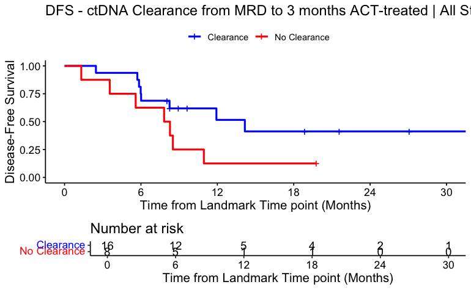

```r
surv_object <-Surv(time = circ_data$DFS.3mo.months, event = circ_data$DFS.Event)
KM_curve <- survfit(surv_object ~ ctDNA.Dynamics, data = circ_data,conf.int=0.95,conf.type="log-log")
ggsurvplot(KM_curve, data = circ_data, pval = FALSE, conf.int = FALSE, risk.table = TRUE, break.time.by=6, palette=c("blue","red"), title="DFS - ctDNA Clearance from MRD to 3 months ACT-treated | All Stages", ylab= "Disease-Free Survival", xlab="Time from Landmark Time point (Months)", legend.labs=c("Clearance", "No Clearance"), legend.title="")
```

```r
summary(KM_curve, times= c(12, 24))
```

```
Call: survfit(formula = surv_object ~ ctDNA.Dynamics, data = circ_data,
    conf.int = 0.95, conf.type = "log-log")

97 observations deleted due to missingness
                ctDNA.Dynamics=1
 time n.risk n.event survival std.err lower 95% CI upper 95% CI
   12      5       7    0.516   0.139        0.229        0.742
   24      2       1    0.413   0.145        0.146        0.665

                ctDNA.Dynamics=2
        time       n.risk      n.event     survival      std.err lower 95% CI upper 95% CI
    12.00000      1.00000      7.00000      0.12500      0.11693      0.00659      0.42271
```

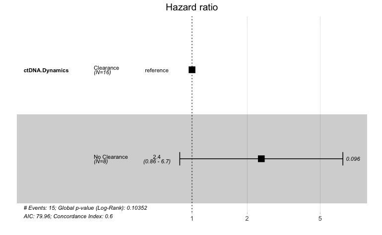

```r
circ_data$ctDNA.Dynamics <- factor(circ_data$ctDNA.Dynamics, levels=c("1","2"), labels = c("Clearance", "No Clearance"))
cox_fit <- coxph(surv_object ~ ctDNA.Dynamics, data=circ_data)
ggforest(cox_fit,data = circ_data)
```

```r
summary(cox_fit)
```

```
Call:
coxph(formula = surv_object ~ ctDNA.Dynamics, data = circ_data)

  n= 24, number of events= 15
   (97 observations deleted due to missingness)

                             coef exp(coef) se(coef)     z Pr(>|z|)
ctDNA.DynamicsNo Clearance 0.8707    2.3885   0.5227 1.666   0.0958 .
---
Signif. codes:  0 ‘***’ 0.001 ‘**’ 0.01 ‘*’ 0.05 ‘.’ 0.1 ‘ ’ 1

                           exp(coef) exp(-coef) lower .95 upper .95
ctDNA.DynamicsNo Clearance     2.389     0.4187    0.8574     6.654

Concordance= 0.605  (se = 0.066 )
Likelihood ratio test= 2.65  on 1 df,   p=0.1
Wald test            = 2.77  on 1 df,   p=0.1
Score (logrank) test = 2.95  on 1 df,   p=0.09
```

```r
cox_fit_summary <- summary(cox_fit)

# Extract values for HR, 95% CI, and p-value
HR <- cox_fit_summary$coefficients[2]
lower_CI <- cox_fit_summary$conf.int[3]
upper_CI <- cox_fit_summary$conf.int[4]
p_value <- cox_fit_summary$coefficients[5]
label_text <- paste0("HR = ", round(HR, 2), " (", round(lower_CI, 2), "-", round(upper_CI, 2), "); p = ", round(p_value, 3))
print(label_text)
```

```
[1] "HR = 2.39 (0.86-6.65); p = 0.096"
```

```r
#Fisher test for DFS percentages at 12 and 24 months
dfs_times <- c(12)
circ_data <- na.omit(circ_data[, c("ctDNA.Dynamics", "DFS.3mo.months", "DFS.Event")])
p_values <- sapply(dfs_times, function(time) {
  neg_count <- sum(circ_data$ctDNA.Dynamics == "Clearance" & circ_data$DFS.3mo.months >= time & circ_data$DFS.Event == FALSE)
  pos_count <- sum(circ_data$ctDNA.Dynamics == "No Clearance" & circ_data$DFS.3mo.months >= time & circ_data$DFS.Event == FALSE)
  neg_total <- sum(circ_data$ctDNA.Dynamics == "Clearance")
  pos_total <- sum(circ_data$ctDNA.Dynamics == "No Clearance")

  neg_surv <- neg_total - sum(circ_data$ctDNA.Dynamics == "Clearance" & circ_data$DFS.Event == TRUE & circ_data$DFS.3mo.months < time)
  pos_surv <- pos_total - sum(circ_data$ctDNA.Dynamics == "No Clearance" & circ_data$DFS.Event == TRUE & circ_data$DFS.3mo.months < time)

  surv_matrix <- matrix(c(neg_surv, pos_surv, neg_total - neg_surv, pos_total - pos_surv), nrow = 2)
  test_result <- fisher.test(surv_matrix)
  return(test_result$p.value)
})
names(p_values) <- paste0("p-value at ", dfs_times, " months")
print(p_values)
```

```
p-value at 12 months
          0.07907586
```

#DFS by ctDNA Clearance ACT-treated at 6 months - all stages

```r
rm(list=ls())
setwd("~/Downloads")
circ_data <- read.csv("Galaxy Data_20240603 Complete Dataset.csv")
circ_data <- circ_data[circ_data$CohortB=="TRUE",]
circ_data <- circ_data[circ_data$ctDNA.MRD!="",]
circ_data <- circ_data[circ_data$ACT==TRUE,]
circ_datadf <- as.data.frame(circ_data)

circ_data$ctDNA.Dynamics <- NA #first we create the variable for the ctDNA & NAC combination, and we assign values
circ_data <- circ_data %>%
  mutate(ctDNA.Dynamics = case_when(
    ctDNA.MRD == "POSITIVE" & ctDNA.6months == "NEGATIVE" ~ 1,
    ctDNA.MRD == "POSITIVE" & ctDNA.6months == "POSITIVE" ~ 2
  ))

circ_data <- circ_data[circ_data$DFS.6mo.months>=0,]
survfit(Surv(time = circ_data$DFS.6mo.months, event = circ_data$DFS.Event)~ctDNA.Dynamics, data = circ_data)
```

```
Call: survfit(formula = Surv(time = circ_data$DFS.6mo.months, event = circ_data$DFS.Event) ~
    ctDNA.Dynamics, data = circ_data)

   106 observations deleted due to missingness
                  n events median 0.95LCL 0.95UCL
ctDNA.Dynamics=1 13      5     NA    5.52      NA
ctDNA.Dynamics=2  2      2   2.68    2.60      NA
```

```r
event_summary <- circ_data %>%
  group_by(ctDNA.Dynamics) %>%
  summarise(
    Total = n(),
    Events = sum(DFS.Event),
    Fraction = Events / n(),
    Percentage = (Events / n()) * 100
  )
print(event_summary)
```

| ctDNA.Dynamics | Total | Events | Fraction | Percentage |
| --- | --- | --- | --- | --- |
| 1 | 13 | 5 | 0.3846154 | 38.46154 |
| 2 | 2 | 2 | 1.0000000 | 100.00000 |
| NA | 106 | NA | NA | NA |

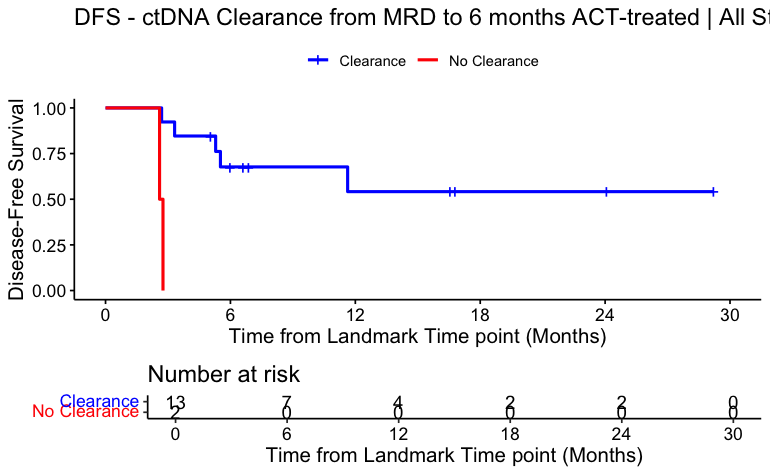

```r
surv_object <-Surv(time = circ_data$DFS.6mo.months, event = circ_data$DFS.Event)
KM_curve <- survfit(surv_object ~ ctDNA.Dynamics, data = circ_data,conf.int=0.95,conf.type="log-log")
ggsurvplot(KM_curve, data = circ_data, pval = FALSE, conf.int = FALSE, risk.table = TRUE, break.time.by=6, palette=c("blue","red"), title="DFS - ctDNA Clearance from MRD to 6 months ACT-treated | All Stages", ylab= "Disease-Free Survival", xlab="Time from Landmark Time point (Months)", legend.labs=c("Clearance", "No Clearance"), legend.title="")
```

```r
summary(KM_curve, times= c(12, 24))
```

```
Call: survfit(formula = surv_object ~ ctDNA.Dynamics, data = circ_data,
    conf.int = 0.95, conf.type = "log-log")

106 observations deleted due to missingness
                ctDNA.Dynamics=1
 time n.risk n.event survival std.err lower 95% CI upper 95% CI
   12      4       5    0.542   0.162        0.204        0.789
   24      2       0    0.542   0.162        0.204        0.789

                ctDNA.Dynamics=2
     time n.risk n.event survival std.err lower 95% CI upper 95% CI
```

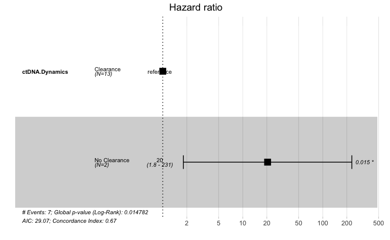

```r
circ_data$ctDNA.Dynamics <- factor(circ_data$ctDNA.Dynamics, levels=c("1","2"), labels = c("Clearance", "No Clearance"))
cox_fit <- coxph(surv_object ~ ctDNA.Dynamics, data=circ_data)
ggforest(cox_fit,data = circ_data)
```

```r
summary(cox_fit)
```

```
Call:
coxph(formula = surv_object ~ ctDNA.Dynamics, data = circ_data)

  n= 15, number of events= 7
   (106 observations deleted due to missingness)

                             coef exp(coef) se(coef)    z Pr(>|z|)
ctDNA.DynamicsNo Clearance  3.017    20.438    1.237 2.44   0.0147 *
---
Signif. codes:  0 ‘***’ 0.001 ‘**’ 0.01 ‘*’ 0.05 ‘.’ 0.1 ‘ ’ 1

                           exp(coef) exp(-coef) lower .95 upper .95
ctDNA.DynamicsNo Clearance     20.44    0.04893      1.81     230.8

Concordance= 0.669  (se = 0.087 )
Likelihood ratio test= 5.94  on 1 df,   p=0.01
Wald test            = 5.95  on 1 df,   p=0.01
Score (logrank) test = 11.68  on 1 df,   p=6e-04
```

```r
cox_fit_summary <- summary(cox_fit)

# Extract values for HR, 95% CI, and p-value
HR <- cox_fit_summary$coefficients[2]
lower_CI <- cox_fit_summary$conf.int[3]
upper_CI <- cox_fit_summary$conf.int[4]
p_value <- cox_fit_summary$coefficients[5]
label_text <- paste0("HR = ", round(HR, 2), " (", round(lower_CI, 2), "-", round(upper_CI, 2), "); p = ", round(p_value, 3))
print(label_text)
```

```
[1] "HR = 20.44 (1.81-230.77); p = 0.015"
```

#Percentages of MRD negative with molecular recurrence (returned positive) post-MRD

```r
rm(list=ls())
setwd("~/Downloads")
circ_data <- read.csv("Galaxy Data_20240603 Complete Dataset.csv")
circ_data <- circ_data[circ_data$CohortB=="TRUE",]
circ_data <- circ_data[circ_data$ctDNA.MRD != "" & circ_data$Lead.Time >= 0, ]
circ_data <- circ_data[circ_data$ctDNA.MRD=="NEGATIVE",]
circ_data <- circ_data[circ_data$PostMRDPos.Event=="TRUE",]
circ_datadf <- as.data.frame(circ_data)

# Convert days to months
circ_data$PostMRDPos.months <- circ_data$PostMRDPos/30.437

# Define the intervals: 0-6, 6-9, 9-12, 12-15, 15-18, 18-21, 21-24, >24 months
breaks <- c(0, 6, 9, 12, 15, 18, 21, 24, 48)
labels <- c("0-6m", "6-9m", "9-12m", "12-15m", "15-18m", "18-21m", "21-24m", ">24m")

# Categorize p_drelReturned_months into intervals
circ_data$p_drelReturned_intervals <- cut(circ_data$PostMRDPos.months, breaks = breaks, labels = labels, right = FALSE)

# Examine the distribution of the intervals
table(circ_data$p_drelReturned_intervals)
```

```
  0-6m   6-9m  9-12m 12-15m 15-18m 18-21m 21-24m   >24m
     9      5      7      1      4      0      0      0
```

```r
# Get the counts for each interval
interval_counts <- table(circ_data$p_drelReturned_intervals)

# Calculate the percentages
interval_percentages <- 100 * interval_counts / sum(interval_counts)

# Combine the counts and percentages for a clearer overview
interval_summary <- data.frame(Counts = interval_counts, Percentages = interval_percentages)

# Calculate the total number of observations
total_observations <- sum(interval_counts)

# Add the total number of observations to the summary
interval_summary$TotalObservations <- c(rep(NA, length(interval_counts)-1), total_observations)

# Print the summary with total observations
print(interval_summary)
```

| Counts.Var1 | Counts.Freq | Percentages.Var1 | Percentages.Freq | TotalObservations |
| --- | --- | --- | --- | --- |
| 0-6m | 9 | 0-6m | 34.615385 | NA |
| 6-9m | 5 | 6-9m | 19.230769 | NA |
| 9-12m | 7 | 9-12m | 26.923077 | NA |
| 12-15m | 1 | 12-15m | 3.846154 | NA |
| 15-18m | 4 | 15-18m | 15.384615 | NA |
| 18-21m | 0 | 18-21m | 0.000000 | NA |
| 21-24m | 0 | 21-24m | 0.000000 | NA |
| >24m | 0 | >24m | 0.000000 | 26 |

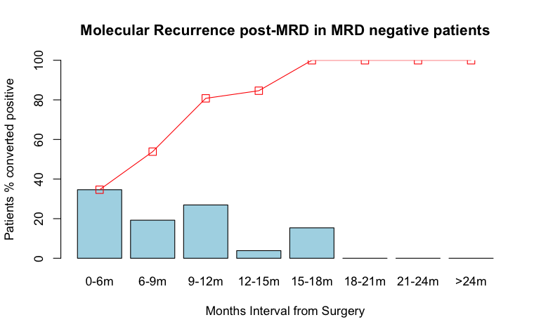

```r
# Calculate cumulative percentages
cumulative_percentages <- cumsum(interval_percentages)

# Combine the counts, percentages, and cumulative percentages for a clearer overview
interval_summary <- data.frame(Counts = interval_counts, Percentages = interval_percentages, CumulativePercentages = cumulative_percentages, TotalObservations = c(rep(NA, length(interval_counts)-1), total_observations))

bp <- barplot(interval_percentages,
              main="Molecular Recurrence post-MRD in MRD negative patients",
              xlab="Months Interval from Surgery",
              ylab="Patients % converted positive",
              col="lightblue",
              ylim=c(0, 100))

# Add the cumulative percentages to the plot
points(bp, cumulative_percentages, type="o", pch=22, col="red", cex=1.5)
```

```r
print(interval_summary)
```

|  | Counts.Var1 | Counts.Freq | Percentages.Var1 | Percentages.Freq | CumulativePercentages | TotalObservations |
| --- | --- | --- | --- | --- | --- | --- |
| 0-6m | 0-6m | 9 | 0-6m | 34.615385 | 34.61538 | NA |
| 6-9m | 6-9m | 5 | 6-9m | 19.230769 | 53.84615 | NA |
| 9-12m | 9-12m | 7 | 9-12m | 26.923077 | 80.76923 | NA |
| 12-15m | 12-15m | 1 | 12-15m | 3.846154 | 84.61538 | NA |
| 15-18m | 15-18m | 4 | 15-18m | 15.384615 | 100.00000 | NA |
| 18-21m | 18-21m | 0 | 18-21m | 0.000000 | 100.00000 | NA |
| 21-24m | 21-24m | 0 | 21-24m | 0.000000 | 100.00000 | NA |
| >24m | >24m | 0 | >24m | 0.000000 | 100.00000 | 26 |

#DFS by ctDNA MRD positive vs ctDNA negative with molecular recurrence at Surveillance - 3 groups

```r
rm(list=ls())
setwd("~/Downloads")
circ_data <- read.csv("Galaxy Data_20240603 Complete Dataset.csv")
circ_data <- circ_data[circ_data$CohortB=="TRUE",]
circ_data <- circ_data[circ_data$ctDNA.MRD!="",]
circ_datadf <- as.data.frame(circ_data)

circ_data$ctDNA.Dynamics <- NA #first we create the variable for the ctDNA & NAC combination, and we assign values
circ_data <- circ_data %>%
  mutate(ctDNA.Dynamics = case_when(
    ctDNA.MRD == "NEGATIVE" & ctDNA.Surveillance=="NEGATIVE" ~ 1,
    ctDNA.MRD == "NEGATIVE" & ctDNA.Surveillance=="POSITIVE" ~ 2,
    ctDNA.MRD == "POSITIVE" ~ 3
  ))

circ_data <- circ_data[circ_data$DFS.MRD.months>=0,]
survfit(Surv(time = circ_data$DFS.MRD.months, event = circ_data$DFS.Event)~ctDNA.Dynamics, data = circ_data)
```

```
Call: survfit(formula = Surv(time = circ_data$DFS.MRD.months, event = circ_data$DFS.Event) ~
    ctDNA.Dynamics, data = circ_data)

   7 observations deleted due to missingness
                   n events median 0.95LCL 0.95UCL
ctDNA.Dynamics=1 180     10     NA      NA      NA
ctDNA.Dynamics=2  24     14  13.44   10.55      NA
ctDNA.Dynamics=3  35     25   9.27    7.62    14.1
```

```r
event_summary <- circ_data %>%
  group_by(ctDNA.Dynamics) %>%
  summarise(
    Total = n(),
    Events = sum(DFS.Event),
    Fraction = Events / n(),
    Percentage = (Events / n()) * 100
  )
print(event_summary)
```

| ctDNA.Dynamics | Total | Events | Fraction | Percentage |
| --- | --- | --- | --- | --- |
| 1 | 180 | 10 | 0.05555556 | 5.555556 |
| 2 | 24 | 14 | 0.58333333 | 58.333333 |
| 3 | 35 | 25 | 0.71428571 | 71.428571 |
| NA | 7 | 4 | 0.57142857 | 57.142857 |

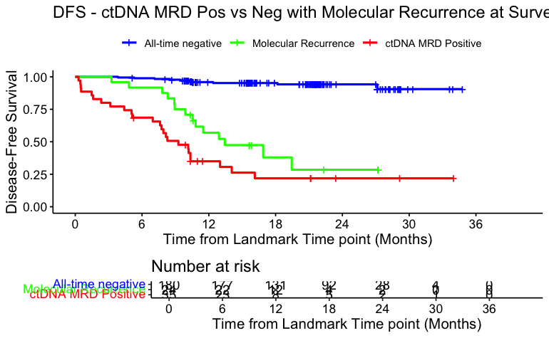

```r
surv_object <-Surv(time = circ_data$DFS.MRD.months, event = circ_data$DFS.Event)
KM_curve <- survfit(surv_object ~ ctDNA.Dynamics, data = circ_data,conf.int=0.95,conf.type="log-log")
ggsurvplot(KM_curve, data = circ_data, pval = FALSE, conf.int = FALSE, risk.table = TRUE, break.time.by=6, palette=c("blue","green","red"), title="DFS - ctDNA MRD Pos vs Neg with Molecular Recurrence at Surveillance Window", ylab= "Disease-Free Survival", xlab="Time from Landmark Time point (Months)", legend.labs=c("All-time negative","Molecular Recurrence", "ctDNA MRD Positive"), legend.title="")
```

```r
summary(KM_curve, times= c(12, 24))
```

```
Call: survfit(formula = surv_object ~ ctDNA.Dynamics, data = circ_data,
    conf.int = 0.95, conf.type = "log-log")

7 observations deleted due to missingness
                ctDNA.Dynamics=1
 time n.risk n.event survival std.err lower 95% CI upper 95% CI
   12    131       7    0.959  0.0151        0.916         0.98
   24     28       2    0.942  0.0194        0.889         0.97

                ctDNA.Dynamics=2
 time n.risk n.event survival std.err lower 95% CI upper 95% CI
   12     12      10    0.569   0.104       0.3457        0.742
   24      2       4    0.285   0.122       0.0863        0.525

                ctDNA.Dynamics=3
 time n.risk n.event survival std.err lower 95% CI upper 95% CI
   12      8      22    0.350  0.0830       0.1948        0.509
   24      2       3    0.219  0.0792       0.0884        0.386
```

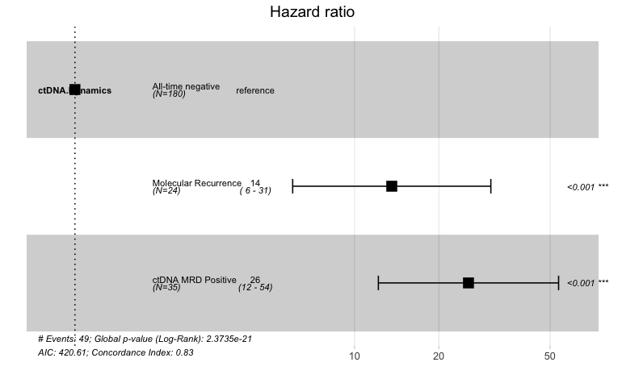

```r
circ_data$ctDNA.Dynamics <- factor(circ_data$ctDNA.Dynamics, levels=c("1","2","3"), labels = c("All-time negative","Molecular Recurrence", "ctDNA MRD Positive"))
cox_fit <- coxph(surv_object ~ ctDNA.Dynamics, data=circ_data)
ggforest(cox_fit,data = circ_data)
```

```r
summary(cox_fit)
```

```
Call:
coxph(formula = surv_object ~ ctDNA.Dynamics, data = circ_data)

  n= 239, number of events= 49
   (7 observations deleted due to missingness)

                                      coef exp(coef) se(coef)     z Pr(>|z|)
ctDNA.DynamicsMolecular Recurrence  2.6086   13.5800   0.4162 6.267 3.68e-10 ***
ctDNA.DynamicsctDNA MRD Positive    3.2402   25.5396   0.3786 8.559  < 2e-16 ***
---
Signif. codes:  0 ‘***’ 0.001 ‘**’ 0.01 ‘*’ 0.05 ‘.’ 0.1 ‘ ’ 1

                                   exp(coef) exp(-coef) lower .95 upper .95
ctDNA.DynamicsMolecular Recurrence     13.58    0.07364     6.006     30.70
ctDNA.DynamicsctDNA MRD Positive       25.54    0.03915    12.162     53.63

Concordance= 0.834  (se = 0.029 )
Likelihood ratio test= 94.98  on 2 df,   p=<2e-16
Wald test            = 74.17  on 2 df,   p=<2e-16
Score (logrank) test = 146.1  on 2 df,   p=<2e-16
```

```r
#Fisher test for DFS percentages at 12 and 24 months - All time negative vs Molecular Recurrence
dfs_times <- c(12, 24)
circ_data <- na.omit(circ_data[, c("ctDNA.Dynamics", "DFS.MRD.months", "DFS.Event")])
p_values <- sapply(dfs_times, function(time) {
  neg_count <- sum(circ_data$ctDNA.Dynamics == "All-time negative" & circ_data$DFS.MRD.months >= time & circ_data$DFS.Event == 0)
  pos_count <- sum(circ_data$ctDNA.Dynamics == "Molecular Recurrence" & circ_data$DFS.MRD.months >= time & circ_data$DFS.Event == 0)
  neg_total <- sum(circ_data$ctDNA.Dynamics == "All-time negative")
  pos_total <- sum(circ_data$ctDNA.Dynamics == "Molecular Recurrence")

  neg_surv <- neg_total - sum(circ_data$ctDNA.Dynamics == "All-time negative" & circ_data$DFS.Event == 1 & circ_data$DFS.MRD.months < time)
  pos_surv <- pos_total - sum(circ_data$ctDNA.Dynamics == "Molecular Recurrence" & circ_data$DFS.Event == 1 & circ_data$DFS.MRD.months < time)

  surv_matrix <- matrix(c(neg_surv, pos_surv, neg_total - neg_surv, pos_total - pos_surv), nrow = 2)
  test_result <- fisher.test(surv_matrix)
  return(test_result$p.value)
})
names(p_values) <- paste0("p-value at ", dfs_times, " months")
print(p_values)
```

```
p-value at 12 months p-value at 24 months
        8.575063e-07         6.424306e-10
```

```r
#Repeat analysis to run Fisher test for All time negative vs ctDNA Positive
rm(list=ls())
setwd("~/Downloads")
circ_data <- read.csv("Galaxy Data_20240603 Complete Dataset.csv")
circ_data <- circ_data[circ_data$CohortB=="TRUE",]
circ_data <- circ_data[circ_data$ctDNA.MRD!="",]

circ_data$ctDNA.Dynamics <- NA #first we create the variable for the ctDNA & NAC combination, and we assign values
circ_data <- circ_data %>%
  mutate(ctDNA.Dynamics = case_when(
    ctDNA.MRD == "NEGATIVE" & ctDNA.Surveillance=="NEGATIVE" ~ 1,
    ctDNA.MRD == "NEGATIVE" & ctDNA.Surveillance=="POSITIVE" ~ 2,
    ctDNA.MRD == "POSITIVE" ~ 3
  ))

circ_data <- circ_data[circ_data$DFS.MRD.months>=0,]

surv_object <-Surv(time = circ_data$DFS.MRD.months, event = circ_data$DFS.Event)
KM_curve <- survfit(surv_object ~ ctDNA.Dynamics, data = circ_data,conf.int=0.95,conf.type="log-log")
summary(KM_curve, times= c(12, 24))
```

```
Call: survfit(formula = surv_object ~ ctDNA.Dynamics, data = circ_data,
    conf.int = 0.95, conf.type = "log-log")

7 observations deleted due to missingness
                ctDNA.Dynamics=1
 time n.risk n.event survival std.err lower 95% CI upper 95% CI
   12    131       7    0.959  0.0151        0.916         0.98
   24     28       2    0.942  0.0194        0.889         0.97

                ctDNA.Dynamics=2
 time n.risk n.event survival std.err lower 95% CI upper 95% CI
   12     12      10    0.569   0.104       0.3457        0.742
   24      2       4    0.285   0.122       0.0863        0.525

                ctDNA.Dynamics=3
 time n.risk n.event survival std.err lower 95% CI upper 95% CI
   12      8      22    0.350  0.0830       0.1948        0.509
   24      2       3    0.219  0.0792       0.0884        0.386
```

```r
circ_data$ctDNA.Dynamics <- factor(circ_data$ctDNA.Dynamics, levels=c("1","2","3"), labels = c("All-time negative","Molecular Recurrence", "ctDNA MRD Positive"))

#Fisher test for DFS percentages at 12 and 24 months - All time negative vs ctDNA Positive
dfs_times <- c(12, 24)
circ_data <- na.omit(circ_data[, c("ctDNA.Dynamics", "DFS.MRD.months", "DFS.Event")])
p_values <- sapply(dfs_times, function(time) {
  neg_count <- sum(circ_data$ctDNA.Dynamics == "All-time negative" & circ_data$DFS.MRD.months >= time & circ_data$DFS.Event == 0)
  pos_count <- sum(circ_data$ctDNA.Dynamics == "ctDNA MRD Positive" & circ_data$DFS.MRD.months >= time & circ_data$DFS.Event == 0)
  neg_total <- sum(circ_data$ctDNA.Dynamics == "All-time negative")
  pos_total <- sum(circ_data$ctDNA.Dynamics == "ctDNA MRD Positive")

  neg_surv <- neg_total - sum(circ_data$ctDNA.Dynamics == "All-time negative" & circ_data$DFS.Event == 1 & circ_data$DFS.MRD.months < time)
  pos_surv <- pos_total - sum(circ_data$ctDNA.Dynamics == "ctDNA MRD Positive" & circ_data$DFS.Event == 1 & circ_data$DFS.MRD.months < time)

  surv_matrix <- matrix(c(neg_surv, pos_surv, neg_total - neg_surv, pos_total - pos_surv), nrow = 2)
  test_result <- fisher.test(surv_matrix)
  return(test_result$p.value)
})
names(p_values) <- paste0("p-value at ", dfs_times, " months")
print(p_values)
```

```
p-value at 12 months p-value at 24 months
        2.382798e-15         1.933852e-17
```

```r
#Repeat analysis to run Fisher test for Molecular Recurrence vs ctDNA Positive
rm(list=ls())
setwd("~/Downloads")
circ_data <- read.csv("Galaxy Data_20240603 Complete Dataset.csv")
circ_data <- circ_data[circ_data$CohortB=="TRUE",]
circ_data <- circ_data[circ_data$ctDNA.MRD!="",]

circ_data$ctDNA.Dynamics <- NA #first we create the variable for the ctDNA & NAC combination, and we assign values
circ_data <- circ_data %>%
  mutate(ctDNA.Dynamics = case_when(
    ctDNA.MRD == "NEGATIVE" & ctDNA.Surveillance=="NEGATIVE" ~ 1,
    ctDNA.MRD == "NEGATIVE" & ctDNA.Surveillance=="POSITIVE" ~ 2,
    ctDNA.MRD == "POSITIVE" ~ 3
  ))

circ_data <- circ_data[circ_data$DFS.MRD.months>=0,]

surv_object <-Surv(time = circ_data$DFS.MRD.months, event = circ_data$DFS.Event)
KM_curve <- survfit(surv_object ~ ctDNA.Dynamics, data = circ_data,conf.int=0.95,conf.type="log-log")
summary(KM_curve, times= c(12, 24))
```

```
Call: survfit(formula = surv_object ~ ctDNA.Dynamics, data = circ_data,
    conf.int = 0.95, conf.type = "log-log")

7 observations deleted due to missingness
                ctDNA.Dynamics=1
 time n.risk n.event survival std.err lower 95% CI upper 95% CI
   12    131       7    0.959  0.0151        0.916         0.98
   24     28       2    0.942  0.0194        0.889         0.97

                ctDNA.Dynamics=2
 time n.risk n.event survival std.err lower 95% CI upper 95% CI
   12     12      10    0.569   0.104       0.3457        0.742
   24      2       4    0.285   0.122       0.0863        0.525

                ctDNA.Dynamics=3
 time n.risk n.event survival std.err lower 95% CI upper 95% CI
   12      8      22    0.350  0.0830       0.1948        0.509
   24      2       3    0.219  0.0792       0.0884        0.386
```

```r
circ_data$ctDNA.Dynamics <- factor(circ_data$ctDNA.Dynamics, levels=c("1","2","3"), labels = c("All-time negative","Molecular Recurrence", "ctDNA MRD Positive"))

#Fisher test for DFS percentages at 12 and 24 months - Molecular Recurrence vs ctDNA Positive
dfs_times <- c(12, 24)
circ_data <- na.omit(circ_data[, c("ctDNA.Dynamics", "DFS.MRD.months", "DFS.Event")])
p_values <- sapply(dfs_times, function(time) {
  neg_count <- sum(circ_data$ctDNA.Dynamics == "Molecular Recurrence" & circ_data$DFS.MRD.months >= time & circ_data$DFS.Event == 0)
  pos_count <- sum(circ_data$ctDNA.Dynamics == "ctDNA MRD Positive" & circ_data$DFS.MRD.months >= time & circ_data$DFS.Event == 0)
  neg_total <- sum(circ_data$ctDNA.Dynamics == "Molecular Recurrence")
  pos_total <- sum(circ_data$ctDNA.Dynamics == "ctDNA MRD Positive")

  neg_surv <- neg_total - sum(circ_data$ctDNA.Dynamics == "Molecular Recurrence" & circ_data$DFS.Event == 1 & circ_data$DFS.MRD.months < time)
  pos_surv <- pos_total - sum(circ_data$ctDNA.Dynamics == "ctDNA MRD Positive" & circ_data$DFS.Event == 1 & circ_data$DFS.MRD.months < time)

  surv_matrix <- matrix(c(neg_surv, pos_surv, neg_total - neg_surv, pos_total - pos_surv), nrow = 2)
  test_result <- fisher.test(surv_matrix)
  return(test_result$p.value)
})
names(p_values) <- paste0("p-value at ", dfs_times, " months")
print(p_values)
```

```
p-value at 12 months p-value at 24 months
           0.1214065            0.4023373
```

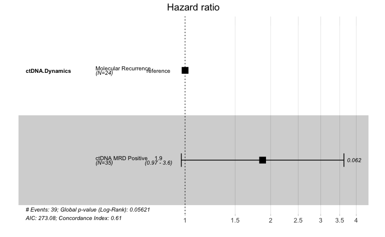

```r
#Repeat to compare HRs for Molecular Recurrence vs ctDNA MRD positive
rm(list=ls())
setwd("~/Downloads")
circ_data <- read.csv("Galaxy Data_20240603 Complete Dataset.csv")
circ_data <- circ_data[circ_data$CohortB=="TRUE",]
circ_data <- circ_data[circ_data$ctDNA.MRD!="",]
circ_datadf <- as.data.frame(circ_data)

circ_data$ctDNA.Dynamics <- NA #first we create the variable for the ctDNA & NAC combination, and we assign values
circ_data <- circ_data %>%
  mutate(ctDNA.Dynamics = case_when(
    ctDNA.MRD == "NEGATIVE" & ctDNA.Surveillance=="NEGATIVE" ~ 1,
    ctDNA.MRD == "NEGATIVE" & ctDNA.Surveillance=="POSITIVE" ~ 2,
    ctDNA.MRD == "POSITIVE" ~ 3
  ))

circ_data <- circ_data[circ_data$DFS.MRD.months>=0,]
surv_object <-Surv(time = circ_data$DFS.MRD.months, event = circ_data$DFS.Event)
circ_data$ctDNA.Dynamics <- factor(circ_data$ctDNA.Dynamics, levels=c("2","3"), labels = c("Molecular Recurrence", "ctDNA MRD Positive"))
cox_fit <- coxph(surv_object ~ ctDNA.Dynamics, data=circ_data)
ggforest(cox_fit,data = circ_data)
```

```r
summary(cox_fit)
```

```
Call:
coxph(formula = surv_object ~ ctDNA.Dynamics, data = circ_data)

  n= 59, number of events= 39
   (187 observations deleted due to missingness)

                                   coef exp(coef) se(coef)     z Pr(>|z|)
ctDNA.DynamicsctDNA MRD Positive 0.6281    1.8741   0.3361 1.869   0.0616 .
---
Signif. codes:  0 ‘***’ 0.001 ‘**’ 0.01 ‘*’ 0.05 ‘.’ 0.1 ‘ ’ 1

                                 exp(coef) exp(-coef) lower .95 upper .95
ctDNA.DynamicsctDNA MRD Positive     1.874     0.5336    0.9699     3.621

Concordance= 0.608  (se = 0.037 )
Likelihood ratio test= 3.65  on 1 df,   p=0.06
Wald test            = 3.49  on 1 df,   p=0.06
Score (logrank) test = 3.6  on 1 df,   p=0.06
```

```r
cox_fit_summary <- summary(cox_fit)

# Extract values for HR, 95% CI, and p-value
HR <- cox_fit_summary$coefficients[2]
lower_CI <- cox_fit_summary$conf.int[3]
upper_CI <- cox_fit_summary$conf.int[4]
p_value <- cox_fit_summary$coefficients[5]
label_text <- paste0("HR = ", round(HR, 2), " (", round(lower_CI, 2), "-", round(upper_CI, 2), "); p = ", round(p_value, 3))
print(label_text)
```

```
[1] "HR = 1.87 (0.97-3.62); p = 0.062"
```

#DFS by ctDNA at the Surveillance Window - All stages Landmark 10 weeks

```r
rm(list=ls())
setwd("~/Downloads")
circ_data <- read.csv("Galaxy Data_20240603 Complete Dataset.csv")
circ_data <- circ_data[circ_data$CohortB=="TRUE",]
circ_data <- circ_data[circ_data$ctDNA.Surveillance!="",]
circ_data$DFS.months=circ_data$DFS.months-2.5
circ_data <- circ_data[circ_data$DFS.months>=0,]
circ_datadf <- as.data.frame(circ_data)

survfit(Surv(time = circ_data$DFS.months, event = circ_data$DFS.Event)~ctDNA.Surveillance, data = circ_data)
```

```
Call: survfit(formula = Surv(time = circ_data$DFS.months, event = circ_data$DFS.Event) ~
    ctDNA.Surveillance, data = circ_data)

                              n events median 0.95LCL 0.95UCL
ctDNA.Surveillance=NEGATIVE 193     10     NA      NA      NA
ctDNA.Surveillance=POSITIVE  40     30   8.79    7.16      12
```

```r
event_summary <- circ_data %>%
  group_by(ctDNA.Surveillance) %>%
  summarise(
    Total = n(),
    Events = sum(DFS.Event),
    Fraction = Events / n(),
    Percentage = (Events / n()) * 100
  )
print(event_summary)
```

| ctDNA.Surveillance | Total | Events | Fraction | Percentage |
| --- | --- | --- | --- | --- |
| NEGATIVE | 193 | 10 | 0.05181347 | 5.181347 |
| POSITIVE | 40 | 30 | 0.75000000 | 75.000000 |

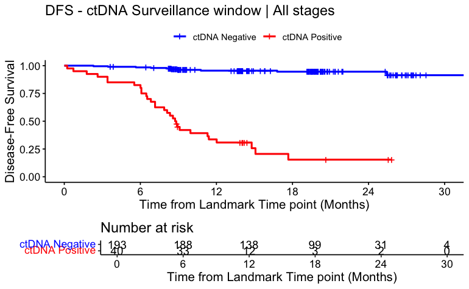

```r
surv_object <-Surv(time = circ_data$DFS.months, event = circ_data$DFS.Event)
KM_curve <- survfit(surv_object ~ ctDNA.Surveillance, data = circ_data,conf.int=0.95,conf.type="log-log")
ggsurvplot(KM_curve, data = circ_data, pval = FALSE, conf.int = FALSE, risk.table = TRUE, break.time.by=6, palette=c("blue","red"), title="DFS - ctDNA Surveillance window | All stages", ylab= "Disease-Free Survival", xlab="Time from Landmark Time point (Months)", legend.labs=c("ctDNA Negative", "ctDNA Positive"), legend.title="")
```

```r
summary(KM_curve, times= c(12, 24))
```

```
Call: survfit(formula = surv_object ~ ctDNA.Surveillance, data = circ_data,
    conf.int = 0.95, conf.type = "log-log")

                ctDNA.Surveillance=NEGATIVE
 time n.risk n.event survival std.err lower 95% CI upper 95% CI
   12    138       8    0.955  0.0156        0.912        0.977
   24     31       1    0.946  0.0181        0.896        0.972

                ctDNA.Surveillance=POSITIVE
 time n.risk n.event survival std.err lower 95% CI upper 95% CI
   12     12      26    0.336  0.0765       0.1940        0.485
   24      2       4    0.154  0.0733       0.0461        0.321
```

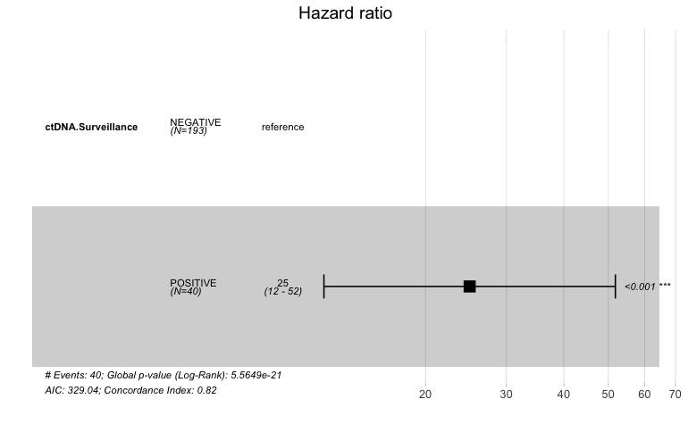

```r
circ_data$ctDNA.Surveillance <- factor(circ_data$ctDNA.Surveillance, levels=c("NEGATIVE","POSITIVE"))
cox_fit <- coxph(surv_object ~ ctDNA.Surveillance, data=circ_data)
ggforest(cox_fit,data = circ_data)
```

```r
summary(cox_fit)
```

```
Call:
coxph(formula = surv_object ~ ctDNA.Surveillance, data = circ_data)

  n= 233, number of events= 40

                              coef exp(coef) se(coef)     z Pr(>|z|)
ctDNA.SurveillancePOSITIVE  3.2170   24.9530   0.3726 8.633   <2e-16 ***
---
Signif. codes:  0 ‘***’ 0.001 ‘**’ 0.01 ‘*’ 0.05 ‘.’ 0.1 ‘ ’ 1

                           exp(coef) exp(-coef) lower .95 upper .95
ctDNA.SurveillancePOSITIVE     24.95    0.04008     12.02      51.8

Concordance= 0.822  (se = 0.033 )
Likelihood ratio test= 88.32  on 1 df,   p=<2e-16
Wald test            = 74.53  on 1 df,   p=<2e-16
Score (logrank) test = 156.3  on 1 df,   p=<2e-16
```

```r
cox_fit_summary <- summary(cox_fit)

# Extract values for HR, 95% CI, and p-value
HR <- cox_fit_summary$coefficients[2]
lower_CI <- cox_fit_summary$conf.int[3]
upper_CI <- cox_fit_summary$conf.int[4]
p_value <- cox_fit_summary$coefficients[5]
label_text <- paste0("HR = ", round(HR, 2), " (", round(lower_CI, 2), "-", round(upper_CI, 2), "); p = ", round(p_value, 3))
print(label_text)
```

```
[1] "HR = 24.95 (12.02-51.8); p = 0"
```

```r
#Fisher test for DFS percentages at 12 and 24 months
dfs_times <- c(12, 24)
circ_data <- na.omit(circ_data[, c("ctDNA.Surveillance", "DFS.months", "DFS.Event")])
p_values <- sapply(dfs_times, function(time) {
  neg_count <- sum(circ_data$ctDNA.Surveillance == "NEGATIVE" & circ_data$DFS.months >= time & circ_data$DFS.Event == 0)
  pos_count <- sum(circ_data$ctDNA.Surveillance == "POSITIVE" & circ_data$DFS.months >= time & circ_data$DFS.Event == 0)
  neg_total <- sum(circ_data$ctDNA.Surveillance == "NEGATIVE")
  pos_total <- sum(circ_data$ctDNA.Surveillance == "POSITIVE")

  neg_surv <- neg_total - sum(circ_data$ctDNA.Surveillance == "NEGATIVE" & circ_data$DFS.Event == 1 & circ_data$DFS.months < time)
  pos_surv <- pos_total - sum(circ_data$ctDNA.Surveillance == "POSITIVE" & circ_data$DFS.Event == 1 & circ_data$DFS.months < time)

  surv_matrix <- matrix(c(neg_surv, pos_surv, neg_total - neg_surv, pos_total - pos_surv), nrow = 2)
  test_result <- fisher.test(surv_matrix)
  return(test_result$p.value)
})
names(p_values) <- paste0("p-value at ", dfs_times, " months")
print(p_values)
```

```
p-value at 12 months p-value at 24 months
        1.175567e-17         2.041854e-21
```

#Multivariate cox regression at Surveillance Window for DFS - All stages Landmark 10 weeks

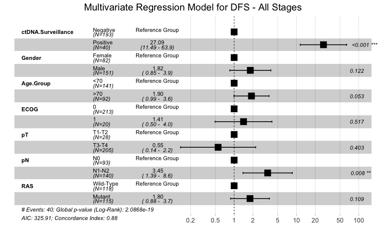

```r
rm(list=ls())
setwd("~/Downloads")
circ_data <- read.csv("Galaxy Data_20240603 Complete Dataset.csv")
circ_data <- circ_data[circ_data$CohortB=="TRUE",]
circ_data <- circ_data[circ_data$ctDNA.Surveillance!="",]
circ_data$DFS.months=circ_data$DFS.months-2.5
circ_data <- circ_data[circ_data$DFS.months>=0,]
circ_datadf <- as.data.frame(circ_data)

circ_data$ctDNA.Surveillance <- factor(circ_data$ctDNA.Surveillance, levels=c("NEGATIVE","POSITIVE"), labels = c("Negative", "Positive"))
circ_data$Gender <- factor(circ_data$Gender, levels = c("Female", "Male"))
circ_data$Age.Group <- factor(circ_data$Age.Group, levels = c("1", "2"), labels = c("<70", ">70"))
circ_data$PrimSite <- factor(circ_data$PrimSite, levels = c("Left-sided colon", "Right-sided colon"))
circ_data$ECOG <- factor(circ_data$ECOG, levels = c("0", "1"))
circ_data$pT <- factor(circ_data$pT, levels = c("T1-T2", "T3-T4"))
circ_data$pN <- factor(circ_data$pN, levels = c("N0", "N1-N2"))
circ_data$RAS <- factor(circ_data$RAS, levels = c("WT", "MUT"), labels = c("Wild-Type", "Mutant"))
surv_object <- Surv(time = circ_data$DFS.months, event = circ_data$DFS.Event)
cox_fit <- coxph(surv_object ~ ctDNA.Surveillance + Gender + Age.Group + ECOG + pT + pN + RAS, data=circ_data)
ggforest(cox_fit, data = circ_data, main = "Multivariate Regression Model for DFS - All Stages", refLabel = "Reference Group")
```

```r
test.ph <- cox.zph(cox_fit)
```

#DFS by ctDNA Dynamics from MRD to 6 months - all stages

```r
rm(list=ls())
setwd("~/Downloads")
circ_data <- read.csv("Galaxy Data_20240603 Complete Dataset.csv")
circ_data <- circ_data[circ_data$CohortB=="TRUE",]
circ_data <- circ_data[circ_data$ctDNA.MRD!="",]
circ_data <- circ_data[circ_data$DFS.6mo.months>=0,]
circ_datadf <- as.data.frame(circ_data)

circ_data$ctDNA.Dynamics <- NA #first we create the variable for the ctDNA & NAC combination, and we assign values
circ_data <- circ_data %>%
  mutate(ctDNA.Dynamics = case_when(
    ctDNA.MRD == "NEGATIVE" & ctDNA.6months == "NEGATIVE" ~ 1,
    ctDNA.MRD == "POSITIVE" & ctDNA.6months == "NEGATIVE" ~ 2,
    ctDNA.MRD == "NEGATIVE" & ctDNA.6months == "POSITIVE" ~ 3,
    ctDNA.MRD == "POSITIVE" & ctDNA.6months == "POSITIVE" ~ 4
  ))

survfit(Surv(time = circ_data$DFS.6mo.months, event = circ_data$DFS.Event)~ctDNA.Dynamics, data = circ_data)
```

```
Call: survfit(formula = Surv(time = circ_data$DFS.6mo.months, event = circ_data$DFS.Event) ~
    ctDNA.Dynamics, data = circ_data)

   66 observations deleted due to missingness
                   n events median 0.95LCL 0.95UCL
ctDNA.Dynamics=1 157     16     NA      NA      NA
ctDNA.Dynamics=2  14      5     NA    5.52      NA
ctDNA.Dynamics=3   4      2   8.51    0.00      NA
ctDNA.Dynamics=4   5      5   2.76    2.60      NA
```

```r
event_summary <- circ_data %>%
  group_by(ctDNA.Dynamics) %>%
  summarise(
    Total = n(),
    Events = sum(DFS.Event),
    Fraction = Events / n(),
    Percentage = (Events / n()) * 100
  )
print(event_summary)
```

| ctDNA.Dynamics | Total | Events | Fraction | Percentage |
| --- | --- | --- | --- | --- |
| 1 | 157 | 16 | 0.1019108 | 10.19108 |
| 2 | 14 | 5 | 0.3571429 | 35.71429 |
| 3 | 4 | 2 | 0.5000000 | 50.00000 |
| 4 | 5 | 5 | 1.0000000 | 100.00000 |
| NA | 66 | NA | NA | NA |

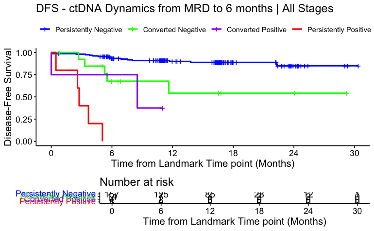

```r
surv_object <-Surv(time = circ_data$DFS.6mo.months, event = circ_data$DFS.Event)
KM_curve <- survfit(surv_object ~ ctDNA.Dynamics, data = circ_data,conf.int=0.95,conf.type="log-log")
ggsurvplot(KM_curve, data = circ_data, pval = FALSE, conf.int = FALSE, risk.table = TRUE, break.time.by=6, palette=c("blue","green","purple", "red"), title="DFS - ctDNA Dynamics from MRD to 6 months | All Stages", ylab= "Disease-Free Survival", xlab="Time from Landmark Time point (Months)", legend.labs=c("Persistently Negative", "Converted Negative","Converted Positive", "Persistently Positive"), legend.title="")
```

```r
summary(KM_curve, times= c(24))
```

```
Call: survfit(formula = surv_object ~ ctDNA.Dynamics, data = circ_data,
    conf.int = 0.95, conf.type = "log-log")

66 observations deleted due to missingness
                ctDNA.Dynamics=1
        time       n.risk      n.event     survival      std.err lower 95% CI upper 95% CI
      24.000       12.000       16.000        0.851        0.045        0.736        0.919

                ctDNA.Dynamics=2
        time       n.risk      n.event     survival      std.err lower 95% CI upper 95% CI
      24.000        2.000        5.000        0.542        0.162        0.204        0.789

                ctDNA.Dynamics=3
     time n.risk n.event survival std.err lower 95% CI upper 95% CI

                ctDNA.Dynamics=4
     time n.risk n.event survival std.err lower 95% CI upper 95% CI
```

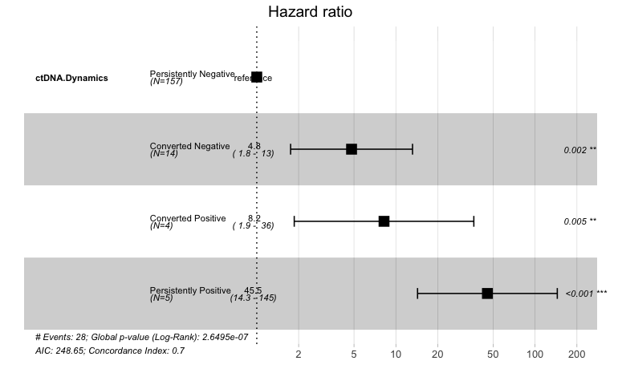

```r
circ_data$ctDNA.Dynamics <- factor(circ_data$ctDNA.Dynamics, levels=c("1","2","3", "4"), labels = c("Persistently Negative", "Converted Negative","Converted Positive", "Persistently Positive"))
cox_fit <- coxph(surv_object ~ ctDNA.Dynamics, data=circ_data)
ggforest(cox_fit,data = circ_data)
```

```r
summary(cox_fit)
```

```
Call:
coxph(formula = surv_object ~ ctDNA.Dynamics, data = circ_data)

  n= 180, number of events= 28
   (66 observations deleted due to missingness)

                                       coef exp(coef) se(coef)     z Pr(>|z|)
ctDNA.DynamicsConverted Negative     1.5689    4.8013   0.5147 3.048  0.00230 **
ctDNA.DynamicsConverted Positive     2.1062    8.2170   0.7582 2.778  0.00547 **
ctDNA.DynamicsPersistently Positive  3.8173   45.4828   0.5900 6.470  9.8e-11 ***
---
Signif. codes:  0 ‘***’ 0.001 ‘**’ 0.01 ‘*’ 0.05 ‘.’ 0.1 ‘ ’ 1

                                    exp(coef) exp(-coef) lower .95 upper .95
ctDNA.DynamicsConverted Negative        4.801    0.20828     1.751     13.17
ctDNA.DynamicsConverted Positive        8.217    0.12170     1.859     36.32
ctDNA.DynamicsPersistently Positive    45.483    0.02199    14.310    144.57

Concordance= 0.697  (se = 0.048 )
Likelihood ratio test= 33.4  on 3 df,   p=3e-07
Wald test            = 46.4  on 3 df,   p=5e-10
Score (logrank) test = 106.2  on 3 df,   p=<2e-16
```

#Table with recurrence sites by ctDNA at the MRD Window

```r
rm(list=ls())
setwd("~/Downloads")
circ_data <- read.csv("Galaxy Data_20240603 Complete Dataset.csv")
circ_data <- circ_data[circ_data$CohortB=="TRUE",]
circ_data <- circ_data[circ_data$RFS.Event=="TRUE",]

circ_data_subset1 <- circ_data %>%
  select(
    Rel.Site) %>%
  mutate(
    Rel.Site = factor(Rel.Site, levels = c("Local", "Lymph Node", "Liver", "Lung", "Peritoneum", "Brain")))

circ_data_subset2 <- circ_data %>%
  select(
    Rel.Site,
    ctDNA.MRD) %>%
  mutate(
    Rel.Site = factor(Rel.Site, levels = c("Local", "Lymph Node", "Liver", "Lung", "Peritoneum", "Brain")),
    ctDNA.MRD = factor(ctDNA.MRD, levels = c("NEGATIVE", "POSITIVE")))
Overall <- circ_data_subset1 %>%
  tbl_summary(
    statistic = list(
      all_continuous() ~ "{median} ({min} - {max})",
      all_categorical() ~ "{n} ({p}%)")) %>%
  bold_labels()
Overall
```

| **Characteristic** | **N = 48**<sup>1</sup> |
| --- | --- |
| Rel.Site |  |
| Local | 4 (8.3%) |
| Lymph Node | 5 (10%) |
| Liver | 17 (35%) |
| Lung | 18 (38%) |
| Peritoneum | 3 (6.3%) |
| Brain | 1 (2.1%) |

<sup>1</sup> n (%)

```r
ByctDNA_MRD <- circ_data_subset2 %>%
  tbl_summary(
    by = ctDNA.MRD, # add this line to subgroup by ctDNA.MRD
    statistic = list(
      all_continuous() ~ "{median} ({min} - {max})",
      all_categorical() ~ "{n} ({p}%)")) %>%
  add_p() %>%
  bold_labels()
ByctDNA_MRD
```

| **Characteristic** | **NEGATIVE**, N = 23<sup>1</sup> | **POSITIVE**, N = 25<sup>1</sup> | **p-value**<sup>2</sup> |
| --- | --- | --- | --- |
| Rel.Site |  |  | <0.001 |
| Local | 2 (8.7%) | 2 (8.0%) |  |
| Lymph Node | 1 (4.3%) | 4 (16%) |  |
| Liver | 2 (8.7%) | 15 (60%) |  |
| Lung | 15 (65%) | 3 (12%) |  |
| Peritoneum | 2 (8.7%) | 1 (4.0%) |  |
| Brain | 1 (4.3%) | 0 (0%) |  |

<sup>1</sup> n (%)  
<sup>2</sup> Fisher’s exact test

```r
merged_table <- tbl_merge(tbls=list(Overall, ByctDNA_MRD))
merged_table
```

| **Characteristic** | **Table 1** **N = 48**<sup>1</sup> | **Table 2** **NEGATIVE**, N = 23<sup>1</sup> | **Table 2** **POSITIVE**, N = 25<sup>1</sup> | **Table 2** **p-value**<sup>2</sup> |
| --- | --- | --- | --- | --- |
| Rel.Site |  |  |  | <0.001 |
| Local | 4 (8.3%) | 2 (8.7%) | 2 (8.0%) |  |
| Lymph Node | 5 (10%) | 1 (4.3%) | 4 (16%) |  |
| Liver | 17 (35%) | 2 (8.7%) | 15 (60%) |  |
| Lung | 18 (38%) | 15 (65%) | 3 (12%) |  |
| Peritoneum | 3 (6.3%) | 2 (8.7%) | 1 (4.0%) |  |
| Brain | 1 (2.1%) | 1 (4.3%) | 0 (0%) |  |

<sup>1</sup> n (%)  
<sup>2</sup> Fisher’s exact test

```r
fit1 <- as_flex_table(
  merged_table,
  include = everything(),
  return_calls = FALSE,
  strip_md_bold = TRUE)
fit1
```

| Characteristic | Table 1 N = 481 | Table 2 NEGATIVE, N = 231 | Table 2 POSITIVE, N = 251 | Table 2 p-value2 |
| --- | --- | --- | --- | --- |
| Rel.Site |  |  |  | <0.001 |
| Local | 4 (8.3%) | 2 (8.7%) | 2 (8.0%) |  |
| Lymph Node | 5 (10%) | 1 (4.3%) | 4 (16%) |  |
| Liver | 17 (35%) | 2 (8.7%) | 15 (60%) |  |
| Lung | 18 (38%) | 15 (65%) | 3 (12%) |  |
| Peritoneum | 3 (6.3%) | 2 (8.7%) | 1 (4.0%) |  |
| Brain | 1 (2.1%) | 1 (4.3%) | 0 (0%) |  |

1n (%)  
2Fisher's exact test

```r
save_as_docx(fit1, path= "~/Downloads/merged_table.docx")
```

#MTM/mL levels at the MRD Window by Radiological Recurrence

```r
rm(list=ls())
setwd("~/Downloads")
circ_data <- read.csv("Galaxy Data_20240603 Complete Dataset.csv")
circ_data <- read.csv("Galaxy Data_20240603 Complete Dataset.csv")
circ_data <- circ_data[circ_data$CohortB=="TRUE",]
circ_data <- circ_data[circ_data$ctDNA.MRD!="",]
circ_data <- circ_data[circ_data$DFS.MRD.months>=0,]
circ_data <- as.data.frame(circ_data)

# Transform p_MRD_MTM with log10
circ_data$p_MRD_MTM <- as.numeric(as.character(circ_data$p_MRD_MTM))
circ_data$RFS.Event <- factor(circ_data$RFS.Event, levels = c("FALSE", "TRUE"), labels = c("No Recurrence", "Recurrence"))
summary_stats <- circ_data %>%
  group_by(RFS.Event) %>%
  summarise(
    median_p_MRD_MTM = median(p_MRD_MTM, na.rm = TRUE),
    range_p_MRD_MTM = paste0(min(p_MRD_MTM, na.rm = TRUE), " - ", max(p_MRD_MTM, na.rm = TRUE))
  )
print(summary_stats)
```

| RFS.Event | median_p_MRD_MTM | range_p_MRD_MTM |
| --- | --- | --- |
| No Recurrence | 0.00000000 | 0 - 9.694491335 |
| Recurrence | 0.06305439 | 0 - 645.7568074 |

```r
m3_1v2 <- wilcox.test(p_MRD_MTM ~ RFS.Event,
                      data = circ_data[circ_data$RFS.Event %in% c("No Recurrence", "Recurrence"), ],
                      na.rm = TRUE)
print(m3_1v2)
```

```
    Wilcoxon rank sum test with continuity correction

data:  p_MRD_MTM by RFS.Event
W = 2458, p-value < 2.2e-16
alternative hypothesis: true location shift is not equal to 0
```

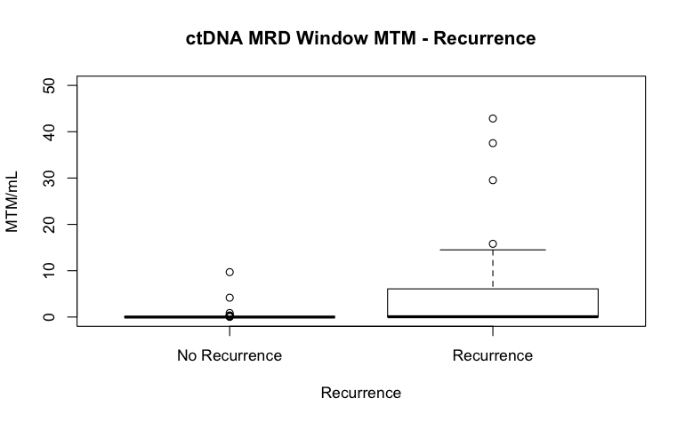

```r
boxplot(p_MRD_MTM~RFS.Event, data=circ_data, main="ctDNA MRD Window MTM - Recurrence", xlab="Recurrence", ylab="MTM/mL", col="white",border="black", ylim = c(0, 50))
```

#MTM/mL levels at the MRD Window by Radiological Recurrence Sites

```r
rm(list=ls())
setwd("~/Downloads")
circ_data <- read.csv("Galaxy Data_20240603 Complete Dataset.csv")
circ_data <- circ_data[circ_data$CohortB=="TRUE",]
circ_data <- circ_data[circ_data$RFS.Event=="TRUE",]
circ_data <- circ_data[circ_data$ctDNA.MRD!="",]
circ_data <- circ_data[circ_data$DFS.MRD.months>=0,]
circ_data <- as.data.frame(circ_data)

# Transform p_MRD_MTM with log10
circ_data$p_MRD_MTM <- as.numeric(as.character(circ_data$p_MRD_MTM))
circ_data$Rel.Site <- factor(circ_data$Rel.Site, levels = c("Liver", "Lymph Node", "Local", "Peritoneum", "Lung", "Brain"))
summary_stats <- circ_data %>%
  group_by(Rel.Site) %>%
  summarise(
    median_p_MRD_MTM = median(p_MRD_MTM, na.rm = TRUE),
    range_p_MRD_MTM = paste0(min(p_MRD_MTM, na.rm = TRUE), " - ", max(p_MRD_MTM, na.rm = TRUE))
  )
print(summary_stats)
```

| Rel.Site | median_p_MRD_MTM | range_p_MRD_MTM |
| --- | --- | --- |
| Liver | 1.66880485 | 0 - 645.7568074 |
| Lymph Node | 4.10239125 | 0 - 42.85542855 |
| Local | 0.07993897 | 0 - 0.2238338905 |
| Peritoneum | 0.00000000 | 0 - 15.80708422 |
| Lung | 0.00000000 | 0 - 11.24115557 |
| Brain | 0.00000000 | 0 - 0 |

```r
kruskal_test <- kruskal.test(p_MRD_MTM ~ Rel.Site, data = circ_data)
print(kruskal_test)
```

```
    Kruskal-Wallis rank sum test

data:  p_MRD_MTM by Rel.Site
Kruskal-Wallis chi-squared = 20.366, df = 5, p-value = 0.001067
```

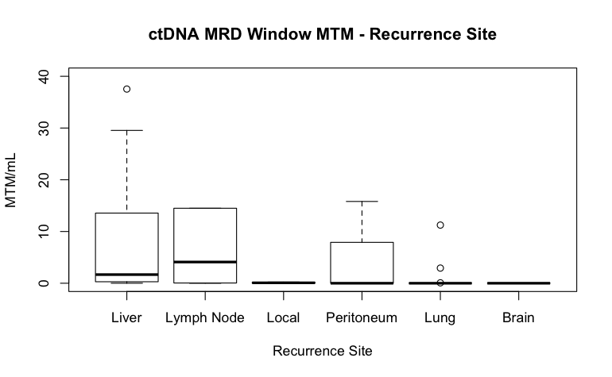

```r
boxplot(p_MRD_MTM~Rel.Site, data=circ_data, main="ctDNA MRD Window MTM - Recurrence Site", xlab="Recurrence Site", ylab="MTM/mL", col="white",border="black", ylim = c(0, 40))
```

```r
rm(list=ls())
setwd("~/Downloads")
circ_data <- read.csv("Galaxy Data_20240603 Complete Dataset.csv")
circ_data <- circ_data[circ_data$CohortB=="TRUE",]
circ_data <- circ_data[circ_data$RFS.Event=="TRUE",]

circ_data$ctDNA.MRD <- factor(circ_data$ctDNA.MRD, levels = c("NEGATIVE", "POSITIVE"), labels = c("Negative", "Positive"))
circ_data$Rel.Site <- factor(circ_data$Rel.Site, levels = c("Liver", "Lymph Node", "Local", "Peritoneum", "Lung", "Brain"))
contingency_table <- table(circ_data$Rel.Site, circ_data$ctDNA.MRD)
chi_square_test <- chisq.test(contingency_table)
print(chi_square_test)
```

```
    Pearson's Chi-squared test

data:  contingency_table
X-squared = 21.028, df = 5, p-value = 0.0008004
```

```r
fisher_exact_test <- fisher.test(contingency_table)
print(fisher_exact_test)
```

```
    Fisher's Exact Test for Count Data

data:  contingency_table
p-value = 5.02e-05
alternative hypothesis: two.sided
```

```r
print(contingency_table)
```

```
             Negative Positive
  Liver             2       15
  Lymph Node        1        4
  Local             2        2
  Peritoneum        2        1
  Lung             15        3
  Brain             1        0
```

[figure not shown]

```r
table_df <- as.data.frame(contingency_table)
table_df$Total <- ave(table_df$Freq, table_df$Var1, FUN = sum)
table_df$Percentage <- table_df$Freq / table_df$Total
table_df$MiddlePercentage <- table_df$Percentage / 2
ggplot(table_df, aes(x = Var1, y = Percentage, fill = Var2)) +
  geom_bar(stat = "identity") +
  geom_text(aes(y = MiddlePercentage, label = Freq), position = "stack", color = "black", vjust = 1.5, size = 7) +
  theme_minimal() +
  labs(title = "Patients with Radiological Recurrence",
       x = "Recurrence Site",
       y = "Patients (%)",
       fill = "ctDNA at MRD",
       caption = paste("Chi-squared test p-value: ", format.pval(chi_square_test$p.value))) +
  scale_y_continuous(labels = scales::percent_format()) +
  scale_fill_manual(values = c("Negative" = "blue", "Positive" = "red")) + # define custom colors
  theme(axis.text.x = element_text(angle = 0, hjust = 1.5, size = 14), # increase x-axis text size
        axis.text.y = element_text(size = 14, color = "black"), # increase y-axis text size
        axis.title.x = element_text(size = 14, color = "black"), # increase x-axis label size
        axis.title.y = element_text(size = 14, color = "black"), # increase y-axis label size
        legend.text = element_text(size = 12, color = "black"))  # increase Recurrence label size
```

#Detection ctDNA rates based on sites of relapse

```r
# Remove existing objects and set the working directory
rm(list=ls())
setwd("~/Downloads")
circ_data <- read.csv("Galaxy Data_20240603 Complete Dataset.csv")
circ_data <- circ_data[circ_data$CohortB=="TRUE",]
circ_data <- circ_data[circ_data$RFS.Event=="TRUE",]

# Create a table of counts for the "Rel.Site" variable
relsite_counts <- table(circ_data$Rel.Site)
relsite_df <- as.data.frame(relsite_counts)
names(relsite_df) <- c("Rel.Site", "Count")
circ_data_pos_mrd <- circ_data[circ_data$ctDNA.MRD=="POSITIVE",]
circ_data_pos_anytime <- circ_data[circ_data$ctDNA.anytime=="POSITIVE",]
pos_counts_mrd <- table(circ_data_pos_mrd$Rel.Site)
pos_counts_anytime <- table(circ_data_pos_anytime$Rel.Site)
relsite_df$MRDPos_Count <- ifelse(is.na(match(relsite_df$Rel.Site, names(pos_counts_mrd))), 0, pos_counts_mrd[match(relsite_df$Rel.Site, names(pos_counts_mrd))])
relsite_df$MRDPos_Count[is.na(relsite_df$MRDPos_Count)] <- 0
relsite_df$AnytimePos_Count <- ifelse(is.na(match(relsite_df$Rel.Site, names(pos_counts_anytime))), 0, pos_counts_anytime[match(relsite_df$Rel.Site, names(pos_counts_anytime))])
relsite_df$AnytimePos_Count[is.na(relsite_df$AnytimePos_Count)] <- 0
relsite_df$Percent <- (relsite_df$Count / sum(relsite_df$Count)) * 100
relsite_df$MRDPos_Percent <- (relsite_df$MRDPos_Count / relsite_df$Count) * 100
relsite_df$AnytimePos_Percent <- (relsite_df$AnytimePos_Count / relsite_df$Count) * 100
total_observations <- sum(relsite_df$Count)
total_pos_mrd <- sum(relsite_df$MRDPos_Count)
total_pos_anytime <- sum(relsite_df$AnytimePos_Count)
total_row <- data.frame(Rel.Site = "Total", Count = total_observations, MRDPos_Count = total_pos_mrd, AnytimePos_Count = total_pos_anytime, Percent = 100, MRDPos_Percent = (total_pos_mrd / total_observations) * 100, AnytimePos_Percent = (total_pos_anytime / total_observations) * 100)
relsite_df <- rbind(relsite_df, total_row)
print(relsite_df)
```

| Rel.Site | Count | MRDPos_Count | AnytimePos_Count | Percent | MRDPos_Percent | AnytimePos_Percent |
| --- | --- | --- | --- | --- | --- | --- |
| Brain | 1 | 0 | 0 | 2.083333 | 0.00000 | 0.00000 |
| Liver | 17 | 15 | 17 | 35.416667 | 88.23529 | 100.00000 |
| Local | 4 | 2 | 4 | 8.333333 | 50.00000 | 100.00000 |
| Lung | 18 | 3 | 10 | 37.500000 | 16.66667 | 55.55556 |
| Lymph Node | 5 | 4 | 5 | 10.416667 | 80.00000 | 100.00000 |
| Peritoneum | 3 | 1 | 3 | 6.250000 | 33.33333 | 100.00000 |
| Total | 48 | 25 | 39 | 100.000000 | 52.08333 | 81.25000 |

```r
ft <- flextable(relsite_df)
doc <- read_docx() %>%
  body_add_flextable(value = ft)
print(doc, target = "relsite_df.docx")
```

#MRD Window - Sensitivity and Specificity calculations - All Cohorts

```r
#All Patients
rm(list=ls())
setwd("~/Downloads")
circ_data <- read.csv("Galaxy Data_20240603 Complete Dataset.csv")
circ_data <- circ_data[circ_data$CohortB=="TRUE",]
circ_data$ctDNA.MRD <- factor(circ_data$ctDNA.MRD, levels=c("NEGATIVE","POSITIVE"))
circ_data$RFS.Event <- factor(circ_data$RFS.Event, levels=c("FALSE","TRUE"))
circ_data$RFS.Event <- factor(ifelse(circ_data$RFS.Event == "FALSE", "NEGATIVE", "POSITIVE"))
conf_matrix <- table(circ_data$ctDNA.MRD, circ_data$RFS.Event)

# Calculate sensitivity and specificity manually
true_positives <- conf_matrix["POSITIVE", "POSITIVE"]
false_negatives <- conf_matrix["NEGATIVE", "POSITIVE"]
true_negatives <- conf_matrix["NEGATIVE", "NEGATIVE"]
false_positives <- conf_matrix["POSITIVE", "NEGATIVE"]
sensitivity <- true_positives / (true_positives + false_negatives)
specificity <- true_negatives / (true_negatives + false_positives)
ppv <- true_positives / (true_positives + false_positives)
npv <- true_negatives / (true_negatives + false_negatives)
print(paste("Sensitivity - All pts: ", sensitivity*100))
```

```
[1] "Sensitivity - All pts:  52.0833333333333"
```

```r
print(paste("Specificity - All pts: ", specificity*100))
```

```
[1] "Specificity - All pts:  94.9748743718593"
```

```r
print(paste("Positive Predictive Value (PPV) - All pts: ", ppv * 100))
```

```
[1] "Positive Predictive Value (PPV) - All pts:  71.4285714285714"
```

```r
print(paste("Negative Predictive Value (NPV) - All pts: ", npv * 100))
```

```
[1] "Negative Predictive Value (NPV) - All pts:  89.1509433962264"
```

```r
#Stage II Patients
rm(list=ls())
setwd("~/Downloads")
circ_data <- read.csv("Galaxy Data_20240603 Complete Dataset.csv")
circ_data <- circ_data[circ_data$CohortB=="TRUE",]
circ_data <- circ_data[circ_data$Stage=="II",]
circ_data$ctDNA.MRD <- factor(circ_data$ctDNA.MRD, levels=c("NEGATIVE","POSITIVE"))
circ_data$RFS.Event <- factor(circ_data$RFS.Event, levels=c("FALSE","TRUE"))
circ_data$RFS.Event <- factor(ifelse(circ_data$RFS.Event == "FALSE", "NEGATIVE", "POSITIVE"))
conf_matrix <- table(circ_data$ctDNA.MRD, circ_data$RFS.Event)

# Calculate sensitivity and specificity manually
true_positives <- conf_matrix["POSITIVE", "POSITIVE"]
false_negatives <- conf_matrix["NEGATIVE", "POSITIVE"]
true_negatives <- conf_matrix["NEGATIVE", "NEGATIVE"]
false_positives <- conf_matrix["POSITIVE", "NEGATIVE"]
sensitivity <- true_positives / (true_positives + false_negatives)
specificity <- true_negatives / (true_negatives + false_positives)
ppv <- true_positives / (true_positives + false_positives)
npv <- true_negatives / (true_negatives + false_negatives)
print(paste("Sensitivity - Stage II: ", sensitivity*100))
```

```
[1] "Sensitivity - Stage II:  37.5"
```

```r
print(paste("Specificity - Stage II: ", specificity*100))
```

```
[1] "Specificity - Stage II:  100"
```

```r
print(paste("Positive Predictive Value (PPV) - Stage II: ", ppv * 100))
```

```
[1] "Positive Predictive Value (PPV) - Stage II:  100"
```

```r
print(paste("Negative Predictive Value (NPV) - Stage II: ", npv * 100))
```

```
[1] "Negative Predictive Value (NPV) - Stage II:  94.7916666666667"
```

```r
#Stage III Patients
rm(list=ls())
setwd("~/Downloads")
circ_data <- read.csv("Galaxy Data_20240603 Complete Dataset.csv")
circ_data <- circ_data[circ_data$CohortB=="TRUE",]
circ_data <- circ_data[circ_data$Stage=="III",]
circ_data$ctDNA.MRD <- factor(circ_data$ctDNA.MRD, levels=c("NEGATIVE","POSITIVE"))
circ_data$RFS.Event <- factor(circ_data$RFS.Event, levels=c("FALSE","TRUE"))
circ_data$RFS.Event <- factor(ifelse(circ_data$RFS.Event == "FALSE", "NEGATIVE", "POSITIVE"))
conf_matrix <- table(circ_data$ctDNA.MRD, circ_data$RFS.Event)

# Calculate sensitivity and specificity manually
true_positives <- conf_matrix["POSITIVE", "POSITIVE"]
false_negatives <- conf_matrix["NEGATIVE", "POSITIVE"]
true_negatives <- conf_matrix["NEGATIVE", "NEGATIVE"]
false_positives <- conf_matrix["POSITIVE", "NEGATIVE"]
sensitivity <- true_positives / (true_positives + false_negatives)
specificity <- true_negatives / (true_negatives + false_positives)
ppv <- true_positives / (true_positives + false_positives)
npv <- true_negatives / (true_negatives + false_negatives)
print(paste("Sensitivity - Stage III: ", sensitivity*100))
```

```
[1] "Sensitivity - Stage III:  55"
```

```r
print(paste("Specificity - Stage III: ", specificity*100))
```

```
[1] "Specificity - Stage III:  90.7407407407407"
```

```r
print(paste("Positive Predictive Value (PPV) - Stage III: ", ppv * 100))
```

```
[1] "Positive Predictive Value (PPV) - Stage III:  68.75"
```

```r
print(paste("Negative Predictive Value (NPV) - Stage III: ", npv * 100))
```

```
[1] "Negative Predictive Value (NPV) - Stage III:  84.4827586206897"
```

#MRD Window - Sensitivity and Specificity calculations - no ACT treated

```r
#All Patients
rm(list=ls())
setwd("~/Downloads")
circ_data <- read.csv("Galaxy Data_20240603 Complete Dataset.csv")
circ_data <- circ_data[circ_data$CohortB=="TRUE",]
circ_data <- circ_data[circ_data$ACT==FALSE,]
circ_data$ctDNA.MRD <- factor(circ_data$ctDNA.MRD, levels=c("NEGATIVE","POSITIVE"))
circ_data$RFS.Event <- factor(circ_data$RFS.Event, levels=c("FALSE","TRUE"))
circ_data$RFS.Event <- factor(ifelse(circ_data$RFS.Event == "FALSE", "NEGATIVE", "POSITIVE"))
conf_matrix <- table(circ_data$ctDNA.MRD, circ_data$RFS.Event)

# Calculate sensitivity and specificity manually
true_positives <- conf_matrix["POSITIVE", "POSITIVE"]
false_negatives <- conf_matrix["NEGATIVE", "POSITIVE"]
true_negatives <- conf_matrix["NEGATIVE", "NEGATIVE"]
false_positives <- conf_matrix["POSITIVE", "NEGATIVE"]
sensitivity <- true_positives / (true_positives + false_negatives)
specificity <- true_negatives / (true_negatives + false_positives)
ppv <- true_positives / (true_positives + false_positives)
npv <- true_negatives / (true_negatives + false_negatives)
print(paste("Sensitivity - All pts: ", sensitivity*100))
```

```
[1] "Sensitivity - All pts:  42.8571428571429"
```

```r
print(paste("Specificity - All pts: ", specificity*100))
```

```
[1] "Specificity - All pts:  99.047619047619"
```

```r
print(paste("Positive Predictive Value (PPV) - All pts: ", ppv * 100))
```

```
[1] "Positive Predictive Value (PPV) - All pts:  90"
```

```r
print(paste("Negative Predictive Value (NPV) - All pts: ", npv * 100))
```

```
[1] "Negative Predictive Value (NPV) - All pts:  89.6551724137931"
```

```r
#Stage II Patients
rm(list=ls())
setwd("~/Downloads")
circ_data <- read.csv("Galaxy Data_20240603 Complete Dataset.csv")
circ_data <- circ_data[circ_data$CohortB=="TRUE",]
circ_data <- circ_data[circ_data$ACT==FALSE,]
circ_data <- circ_data[circ_data$Stage=="II",]
circ_data$ctDNA.MRD <- factor(circ_data$ctDNA.MRD, levels=c("NEGATIVE","POSITIVE"))
circ_data$RFS.Event <- factor(circ_data$RFS.Event, levels=c("FALSE","TRUE"))
circ_data$RFS.Event <- factor(ifelse(circ_data$RFS.Event == "FALSE", "NEGATIVE", "POSITIVE"))
conf_matrix <- table(circ_data$ctDNA.MRD, circ_data$RFS.Event)

# Calculate sensitivity and specificity manually
true_positives <- conf_matrix["POSITIVE", "POSITIVE"]
false_negatives <- conf_matrix["NEGATIVE", "POSITIVE"]
true_negatives <- conf_matrix["NEGATIVE", "NEGATIVE"]
false_positives <- conf_matrix["POSITIVE", "NEGATIVE"]
sensitivity <- true_positives / (true_positives + false_negatives)
specificity <- true_negatives / (true_negatives + false_positives)
ppv <- true_positives / (true_positives + false_positives)
npv <- true_negatives / (true_negatives + false_negatives)
print(paste("Sensitivity - Stage II: ", sensitivity*100))
```

```
[1] "Sensitivity - Stage II:  16.6666666666667"
```

```r
print(paste("Specificity - Stage II: ", specificity*100))
```

```
[1] "Specificity - Stage II:  100"
```

```r
print(paste("Positive Predictive Value (PPV) - Stage II: ", ppv * 100))
```

```
[1] "Positive Predictive Value (PPV) - Stage II:  100"
```

```r
print(paste("Negative Predictive Value (NPV) - Stage II: ", npv * 100))
```

```
[1] "Negative Predictive Value (NPV) - Stage II:  93.3333333333333"
```

```r
#Stage III Patients
rm(list=ls())
setwd("~/Downloads")
circ_data <- read.csv("Galaxy Data_20240603 Complete Dataset.csv")
circ_data <- circ_data[circ_data$CohortB=="TRUE",]
circ_data <- circ_data[circ_data$ACT==FALSE,]
circ_data <- circ_data[circ_data$Stage=="III",]
circ_data$ctDNA.MRD <- factor(circ_data$ctDNA.MRD, levels=c("NEGATIVE","POSITIVE"))
circ_data$RFS.Event <- factor(circ_data$RFS.Event, levels=c("FALSE","TRUE"))
circ_data$RFS.Event <- factor(ifelse(circ_data$RFS.Event == "FALSE", "NEGATIVE", "POSITIVE"))
conf_matrix <- table(circ_data$ctDNA.MRD, circ_data$RFS.Event)

# Calculate sensitivity and specificity manually
true_positives <- conf_matrix["POSITIVE", "POSITIVE"]
false_negatives <- conf_matrix["NEGATIVE", "POSITIVE"]
true_negatives <- conf_matrix["NEGATIVE", "NEGATIVE"]
false_positives <- conf_matrix["POSITIVE", "NEGATIVE"]
sensitivity <- true_positives / (true_positives + false_negatives)
specificity <- true_negatives / (true_negatives + false_positives)
ppv <- true_positives / (true_positives + false_positives)
npv <- true_negatives / (true_negatives + false_negatives)
print(paste("Sensitivity - Stage III: ", sensitivity*100))
```

```
[1] "Sensitivity - Stage III:  53.3333333333333"
```

```r
print(paste("Specificity - Stage III: ", specificity*100))
```

```
[1] "Specificity - Stage III:  97.1428571428571"
```

```r
print(paste("Positive Predictive Value (PPV) - Stage III: ", ppv * 100))
```

```
[1] "Positive Predictive Value (PPV) - Stage III:  88.8888888888889"
```

```r
print(paste("Negative Predictive Value (NPV) - Stage III: ", npv * 100))
```

```
[1] "Negative Predictive Value (NPV) - Stage III:  82.9268292682927"
```

#MRD Window - Sensitivity and Specificity calculations - ACT treated

```r
#All Patients
rm(list=ls())
setwd("~/Downloads")
circ_data <- read.csv("Galaxy Data_20240603 Complete Dataset.csv")
circ_data <- circ_data[circ_data$CohortB=="TRUE",]
circ_data <- circ_data[circ_data$ACT==TRUE,]
circ_data$ctDNA.MRD <- factor(circ_data$ctDNA.MRD, levels=c("NEGATIVE","POSITIVE"))
circ_data$RFS.Event <- factor(circ_data$RFS.Event, levels=c("FALSE","TRUE"))
circ_data$RFS.Event <- factor(ifelse(circ_data$RFS.Event == "FALSE", "NEGATIVE", "POSITIVE"))
conf_matrix <- table(circ_data$ctDNA.MRD, circ_data$RFS.Event)

# Calculate sensitivity and specificity manually
true_positives <- conf_matrix["POSITIVE", "POSITIVE"]
false_negatives <- conf_matrix["NEGATIVE", "POSITIVE"]
true_negatives <- conf_matrix["NEGATIVE", "NEGATIVE"]
false_positives <- conf_matrix["POSITIVE", "NEGATIVE"]
sensitivity <- true_positives / (true_positives + false_negatives)
specificity <- true_negatives / (true_negatives + false_positives)
ppv <- true_positives / (true_positives + false_positives)
npv <- true_negatives / (true_negatives + false_negatives)
print(paste("Sensitivity - All pts: ", sensitivity*100))
```

```
[1] "Sensitivity - All pts:  59.2592592592593"
```

```r
print(paste("Specificity - All pts: ", specificity*100))
```

```
[1] "Specificity - All pts:  90.4255319148936"
```

```r
print(paste("Positive Predictive Value (PPV) - All pts: ", ppv * 100))
```

```
[1] "Positive Predictive Value (PPV) - All pts:  64"
```

```r
print(paste("Negative Predictive Value (NPV) - All pts: ", npv * 100))
```

```
[1] "Negative Predictive Value (NPV) - All pts:  88.5416666666667"
```

```r
#Stage II Patients
rm(list=ls())
setwd("~/Downloads")
circ_data <- read.csv("Galaxy Data_20240603 Complete Dataset.csv")
circ_data <- circ_data[circ_data$CohortB=="TRUE",]
circ_data <- circ_data[circ_data$ACT==TRUE,]
circ_data <- circ_data[circ_data$Stage=="II",]
circ_data$ctDNA.MRD <- factor(circ_data$ctDNA.MRD, levels=c("NEGATIVE","POSITIVE"))
circ_data$RFS.Event <- factor(circ_data$RFS.Event, levels=c("FALSE","TRUE"))
circ_data$RFS.Event <- factor(ifelse(circ_data$RFS.Event == "FALSE", "NEGATIVE", "POSITIVE"))
conf_matrix <- table(circ_data$ctDNA.MRD, circ_data$RFS.Event)

# Calculate sensitivity and specificity manually
true_positives <- conf_matrix["POSITIVE", "POSITIVE"]
false_negatives <- conf_matrix["NEGATIVE", "POSITIVE"]
true_negatives <- conf_matrix["NEGATIVE", "NEGATIVE"]
false_positives <- conf_matrix["POSITIVE", "NEGATIVE"]
sensitivity <- true_positives / (true_positives + false_negatives)
specificity <- true_negatives / (true_negatives + false_positives)
ppv <- true_positives / (true_positives + false_positives)
npv <- true_negatives / (true_negatives + false_negatives)
print(paste("Sensitivity - Stage II: ", sensitivity*100))
```

```
[1] "Sensitivity - Stage II:  100"
```

```r
print(paste("Specificity - Stage II: ", specificity*100))
```

```
[1] "Specificity - Stage II:  100"
```

```r
print(paste("Positive Predictive Value (PPV) - Stage II: ", ppv * 100))
```

```
[1] "Positive Predictive Value (PPV) - Stage II:  100"
```

```r
print(paste("Negative Predictive Value (NPV) - Stage II: ", npv * 100))
```

```
[1] "Negative Predictive Value (NPV) - Stage II:  100"
```

```r
#Stage III Patients
rm(list=ls())
setwd("~/Downloads")
circ_data <- read.csv("Galaxy Data_20240603 Complete Dataset.csv")
circ_data <- circ_data[circ_data$CohortB=="TRUE",]
circ_data <- circ_data[circ_data$ACT==TRUE,]
circ_data <- circ_data[circ_data$Stage=="III",]
circ_data$ctDNA.MRD <- factor(circ_data$ctDNA.MRD, levels=c("NEGATIVE","POSITIVE"))
circ_data$RFS.Event <- factor(circ_data$RFS.Event, levels=c("FALSE","TRUE"))
circ_data$RFS.Event <- factor(ifelse(circ_data$RFS.Event == "FALSE", "NEGATIVE", "POSITIVE"))
conf_matrix <- table(circ_data$ctDNA.MRD, circ_data$RFS.Event)

# Calculate sensitivity and specificity manually
true_positives <- conf_matrix["POSITIVE", "POSITIVE"]
false_negatives <- conf_matrix["NEGATIVE", "POSITIVE"]
true_negatives <- conf_matrix["NEGATIVE", "NEGATIVE"]
false_positives <- conf_matrix["POSITIVE", "NEGATIVE"]
sensitivity <- true_positives / (true_positives + false_negatives)
specificity <- true_negatives / (true_negatives + false_positives)
ppv <- true_positives / (true_positives + false_positives)
npv <- true_negatives / (true_negatives + false_negatives)
print(paste("Sensitivity - Stage III: ", sensitivity*100))
```

```
[1] "Sensitivity - Stage III:  56"
```

```r
print(paste("Specificity - Stage III: ", specificity*100))
```

```
[1] "Specificity - Stage III:  87.6712328767123"
```

```r
print(paste("Positive Predictive Value (PPV) - Stage III: ", ppv * 100))
```

```
[1] "Positive Predictive Value (PPV) - Stage III:  60.8695652173913"
```

```r
print(paste("Negative Predictive Value (NPV) - Stage III: ", npv * 100))
```

```
[1] "Negative Predictive Value (NPV) - Stage III:  85.3333333333333"
```

#Surveillance Window - Sensitivity and Specificity calculations - All Cohorts

```r
#All Patients
rm(list=ls())
setwd("~/Downloads")
circ_data <- read.csv("Galaxy Data_20240603 Complete Dataset.csv")
circ_data <- circ_data[circ_data$CohortB=="TRUE",]
circ_data$ctDNA.Surveillance <- factor(circ_data$ctDNA.Surveillance, levels=c("NEGATIVE","POSITIVE"))
circ_data$RFS.Event <- factor(circ_data$RFS.Event, levels=c("FALSE","TRUE"))
circ_data$RFS.Event <- factor(ifelse(circ_data$RFS.Event == "FALSE", "NEGATIVE", "POSITIVE"))
conf_matrix <- table(circ_data$ctDNA.Surveillance, circ_data$RFS.Event)

# Calculate sensitivity and specificity manually
true_positives <- conf_matrix["POSITIVE", "POSITIVE"]
false_negatives <- conf_matrix["NEGATIVE", "POSITIVE"]
true_negatives <- conf_matrix["NEGATIVE", "NEGATIVE"]
false_positives <- conf_matrix["POSITIVE", "NEGATIVE"]
sensitivity <- true_positives / (true_positives + false_negatives)
specificity <- true_negatives / (true_negatives + false_positives)
ppv <- true_positives / (true_positives + false_positives)
npv <- true_negatives / (true_negatives + false_negatives)
print(paste("Sensitivity - All pts: ", sensitivity*100))
```

```
[1] "Sensitivity - All pts:  83.3333333333333"
```

```r
print(paste("Specificity - All pts: ", specificity*100))
```

```
[1] "Specificity - All pts:  94.9238578680203"
```

```r
print(paste("Positive Predictive Value (PPV) - All pts: ", ppv * 100))
```

```
[1] "Positive Predictive Value (PPV) - All pts:  75"
```

```r
print(paste("Negative Predictive Value (NPV) - All pts: ", npv * 100))
```

```
[1] "Negative Predictive Value (NPV) - All pts:  96.8911917098446"
```

```r
#Stage II Patients
rm(list=ls())
setwd("~/Downloads")
circ_data <- read.csv("Galaxy Data_20240603 Complete Dataset.csv")
circ_data <- circ_data[circ_data$CohortB=="TRUE",]
circ_data <- circ_data[circ_data$Stage=="II",]
circ_data$ctDNA.Surveillance <- factor(circ_data$ctDNA.Surveillance, levels=c("NEGATIVE","POSITIVE"))
circ_data$RFS.Event <- factor(circ_data$RFS.Event, levels=c("FALSE","TRUE"))
circ_data$RFS.Event <- factor(ifelse(circ_data$RFS.Event == "FALSE", "NEGATIVE", "POSITIVE"))
conf_matrix <- table(circ_data$ctDNA.Surveillance, circ_data$RFS.Event)

# Calculate sensitivity and specificity manually
true_positives <- conf_matrix["POSITIVE", "POSITIVE"]
false_negatives <- conf_matrix["NEGATIVE", "POSITIVE"]
true_negatives <- conf_matrix["NEGATIVE", "NEGATIVE"]
false_positives <- conf_matrix["POSITIVE", "NEGATIVE"]
sensitivity <- true_positives / (true_positives + false_negatives)
specificity <- true_negatives / (true_negatives + false_positives)
ppv <- true_positives / (true_positives + false_positives)
npv <- true_negatives / (true_negatives + false_negatives)
print(paste("Sensitivity - Stage II: ", sensitivity*100))
```

```
[1] "Sensitivity - Stage II:  100"
```

```r
print(paste("Specificity - Stage II: ", specificity*100))
```

```
[1] "Specificity - Stage II:  96.6292134831461"
```

```r
print(paste("Positive Predictive Value (PPV) - Stage II: ", ppv * 100))
```

```
[1] "Positive Predictive Value (PPV) - Stage II:  62.5"
```

```r
print(paste("Negative Predictive Value (NPV) - Stage II: ", npv * 100))
```

```
[1] "Negative Predictive Value (NPV) - Stage II:  100"
```

```r
#Stage III Patients
rm(list=ls())
setwd("~/Downloads")
circ_data <- read.csv("Galaxy Data_20240603 Complete Dataset.csv")
circ_data <- circ_data[circ_data$CohortB=="TRUE",]
circ_data <- circ_data[circ_data$Stage=="III",]
circ_data$ctDNA.Surveillance <- factor(circ_data$ctDNA.Surveillance, levels=c("NEGATIVE","POSITIVE"))
circ_data$RFS.Event <- factor(circ_data$RFS.Event, levels=c("FALSE","TRUE"))
circ_data$RFS.Event <- factor(ifelse(circ_data$RFS.Event == "FALSE", "NEGATIVE", "POSITIVE"))
conf_matrix <- table(circ_data$ctDNA.Surveillance, circ_data$RFS.Event)

# Calculate sensitivity and specificity manually
true_positives <- conf_matrix["POSITIVE", "POSITIVE"]
false_negatives <- conf_matrix["NEGATIVE", "POSITIVE"]
true_negatives <- conf_matrix["NEGATIVE", "NEGATIVE"]
false_positives <- conf_matrix["POSITIVE", "NEGATIVE"]
sensitivity <- true_positives / (true_positives + false_negatives)
specificity <- true_negatives / (true_negatives + false_positives)
ppv <- true_positives / (true_positives + false_positives)
npv <- true_negatives / (true_negatives + false_negatives)
print(paste("Sensitivity - Stage III: ", sensitivity*100))
```

```
[1] "Sensitivity - Stage III:  80.6451612903226"
```

```r
print(paste("Specificity - Stage III: ", specificity*100))
```

```
[1] "Specificity - Stage III:  93.5185185185185"
```

```r
print(paste("Positive Predictive Value (PPV) - Stage III: ", ppv * 100))
```

```
[1] "Positive Predictive Value (PPV) - Stage III:  78.125"
```

```r
print(paste("Negative Predictive Value (NPV) - Stage III: ", npv * 100))
```

```
[1] "Negative Predictive Value (NPV) - Stage III:  94.392523364486"
```

#Surveillance Window - Sensitivity and Specificity calculations - non ACT treated

```r
#All Patients
rm(list=ls())
setwd("~/Downloads")
circ_data <- read.csv("Galaxy Data_20240603 Complete Dataset.csv")
circ_data <- circ_data[circ_data$CohortB=="TRUE",]
circ_data <- circ_data[circ_data$ACT==FALSE,]
circ_data$ctDNA.Surveillance <- factor(circ_data$ctDNA.Surveillance, levels=c("NEGATIVE","POSITIVE"))
circ_data$RFS.Event <- factor(circ_data$RFS.Event, levels=c("FALSE","TRUE"))
circ_data$RFS.Event <- factor(ifelse(circ_data$RFS.Event == "FALSE", "NEGATIVE", "POSITIVE"))
conf_matrix <- table(circ_data$ctDNA.Surveillance, circ_data$RFS.Event)

# Calculate sensitivity and specificity manually
true_positives <- conf_matrix["POSITIVE", "POSITIVE"]
false_negatives <- conf_matrix["NEGATIVE", "POSITIVE"]
true_negatives <- conf_matrix["NEGATIVE", "NEGATIVE"]
false_positives <- conf_matrix["POSITIVE", "NEGATIVE"]
sensitivity <- true_positives / (true_positives + false_negatives)
specificity <- true_negatives / (true_negatives + false_positives)
ppv <- true_positives / (true_positives + false_positives)
npv <- true_negatives / (true_negatives + false_negatives)
print(paste("Sensitivity - All pts: ", sensitivity*100))
```

```
[1] "Sensitivity - All pts:  100"
```

```r
print(paste("Specificity - All pts: ", specificity*100))
```

```
[1] "Specificity - All pts:  95.0980392156863"
```

```r
print(paste("Positive Predictive Value (PPV) - All pts: ", ppv * 100))
```

```
[1] "Positive Predictive Value (PPV) - All pts:  75"
```

```r
print(paste("Negative Predictive Value (NPV) - All pts: ", npv * 100))
```

```
[1] "Negative Predictive Value (NPV) - All pts:  100"
```

```r
#Stage II Patients
rm(list=ls())
setwd("~/Downloads")
circ_data <- read.csv("Galaxy Data_20240603 Complete Dataset.csv")
circ_data <- circ_data[circ_data$CohortB=="TRUE",]
circ_data <- circ_data[circ_data$ACT==FALSE,]
circ_data <- circ_data[circ_data$Stage=="II",]
circ_data$ctDNA.Surveillance <- factor(circ_data$ctDNA.Surveillance, levels=c("NEGATIVE","POSITIVE"))
circ_data$RFS.Event <- factor(circ_data$RFS.Event, levels=c("FALSE","TRUE"))
circ_data$RFS.Event <- factor(ifelse(circ_data$RFS.Event == "FALSE", "NEGATIVE", "POSITIVE"))
conf_matrix <- table(circ_data$ctDNA.Surveillance, circ_data$RFS.Event)

# Calculate sensitivity and specificity manually
true_positives <- conf_matrix["POSITIVE", "POSITIVE"]
false_negatives <- conf_matrix["NEGATIVE", "POSITIVE"]
true_negatives <- conf_matrix["NEGATIVE", "NEGATIVE"]
false_positives <- conf_matrix["POSITIVE", "NEGATIVE"]
sensitivity <- true_positives / (true_positives + false_negatives)
specificity <- true_negatives / (true_negatives + false_positives)
ppv <- true_positives / (true_positives + false_positives)
npv <- true_negatives / (true_negatives + false_negatives)
print(paste("Sensitivity - Stage II: ", sensitivity*100))
```

```
[1] "Sensitivity - Stage II:  100"
```

```r
print(paste("Specificity - Stage II: ", specificity*100))
```

```
[1] "Specificity - Stage II:  95.5223880597015"
```

```r
print(paste("Positive Predictive Value (PPV) - Stage II: ", ppv * 100))
```

```
[1] "Positive Predictive Value (PPV) - Stage II:  57.1428571428571"
```

```r
print(paste("Negative Predictive Value (NPV) - Stage II: ", npv * 100))
```

```
[1] "Negative Predictive Value (NPV) - Stage II:  100"
```

```r
#Stage III Patients
rm(list=ls())
setwd("~/Downloads")
circ_data <- read.csv("Galaxy Data_20240603 Complete Dataset.csv")
circ_data <- circ_data[circ_data$CohortB=="TRUE",]
circ_data <- circ_data[circ_data$ACT==FALSE,]
circ_data <- circ_data[circ_data$Stage=="III",]
circ_data$ctDNA.Surveillance <- factor(circ_data$ctDNA.Surveillance, levels=c("NEGATIVE","POSITIVE"))
circ_data$RFS.Event <- factor(circ_data$RFS.Event, levels=c("FALSE","TRUE"))
circ_data$RFS.Event <- factor(ifelse(circ_data$RFS.Event == "FALSE", "NEGATIVE", "POSITIVE"))
conf_matrix <- table(circ_data$ctDNA.Surveillance, circ_data$RFS.Event)

# Calculate sensitivity and specificity manually
true_positives <- conf_matrix["POSITIVE", "POSITIVE"]
false_negatives <- conf_matrix["NEGATIVE", "POSITIVE"]
true_negatives <- conf_matrix["NEGATIVE", "NEGATIVE"]
false_positives <- conf_matrix["POSITIVE", "NEGATIVE"]
sensitivity <- true_positives / (true_positives + false_negatives)
specificity <- true_negatives / (true_negatives + false_positives)
ppv <- true_positives / (true_positives + false_positives)
npv <- true_negatives / (true_negatives + false_negatives)
print(paste("Sensitivity - Stage III: ", sensitivity*100))
```

```
[1] "Sensitivity - Stage III:  100"
```

```r
print(paste("Specificity - Stage III: ", specificity*100))
```

```
[1] "Specificity - Stage III:  94.2857142857143"
```

```r
print(paste("Positive Predictive Value (PPV) - Stage III: ", ppv * 100))
```

```
[1] "Positive Predictive Value (PPV) - Stage III:  84.6153846153846"
```

```r
print(paste("Negative Predictive Value (NPV) - Stage III: ", npv * 100))
```

```
[1] "Negative Predictive Value (NPV) - Stage III:  100"
```

#Surveillance Window - Sensitivity and Specificity calculations - ACT treated

```r
#All Patients
rm(list=ls())
setwd("~/Downloads")
circ_data <- read.csv("Galaxy Data_20240603 Complete Dataset.csv")
circ_data <- circ_data[circ_data$CohortB=="TRUE",]
circ_data <- circ_data[circ_data$ACT==TRUE,]
circ_data$ctDNA.Surveillance <- factor(circ_data$ctDNA.Surveillance, levels=c("NEGATIVE","POSITIVE"))
circ_data$RFS.Event <- factor(circ_data$RFS.Event, levels=c("FALSE","TRUE"))
circ_data$RFS.Event <- factor(ifelse(circ_data$RFS.Event == "FALSE", "NEGATIVE", "POSITIVE"))
conf_matrix <- table(circ_data$ctDNA.Surveillance, circ_data$RFS.Event)

# Calculate sensitivity and specificity manually
true_positives <- conf_matrix["POSITIVE", "POSITIVE"]
false_negatives <- conf_matrix["NEGATIVE", "POSITIVE"]
true_negatives <- conf_matrix["NEGATIVE", "NEGATIVE"]
false_positives <- conf_matrix["POSITIVE", "NEGATIVE"]
sensitivity <- true_positives / (true_positives + false_negatives)
specificity <- true_negatives / (true_negatives + false_positives)
ppv <- true_positives / (true_positives + false_positives)
npv <- true_negatives / (true_negatives + false_negatives)
print(paste("Sensitivity - All pts: ", sensitivity*100))
```

```
[1] "Sensitivity - All pts:  71.4285714285714"
```

```r
print(paste("Specificity - All pts: ", specificity*100))
```

```
[1] "Specificity - All pts:  94.7368421052632"
```

```r
print(paste("Positive Predictive Value (PPV) - All pts: ", ppv * 100))
```

```
[1] "Positive Predictive Value (PPV) - All pts:  75"
```

```r
print(paste("Negative Predictive Value (NPV) - All pts: ", npv * 100))
```

```
[1] "Negative Predictive Value (NPV) - All pts:  93.75"
```

```r
#Stage II Patients
rm(list=ls())
setwd("~/Downloads")
circ_data <- read.csv("Galaxy Data_20240603 Complete Dataset.csv")
circ_data <- circ_data[circ_data$CohortB=="TRUE",]
circ_data <- circ_data[circ_data$ACT==TRUE,]
circ_data <- circ_data[circ_data$Stage=="II",]
circ_data$ctDNA.Surveillance <- factor(circ_data$ctDNA.Surveillance, levels=c("NEGATIVE","POSITIVE"))
circ_data$RFS.Event <- factor(circ_data$RFS.Event, levels=c("FALSE","TRUE"))
circ_data$RFS.Event <- factor(ifelse(circ_data$RFS.Event == "FALSE", "NEGATIVE", "POSITIVE"))
conf_matrix <- table(circ_data$ctDNA.Surveillance, circ_data$RFS.Event)

# Calculate sensitivity and specificity manually
true_positives <- conf_matrix["POSITIVE", "POSITIVE"]
false_negatives <- conf_matrix["NEGATIVE", "POSITIVE"]
true_negatives <- conf_matrix["NEGATIVE", "NEGATIVE"]
false_positives <- conf_matrix["POSITIVE", "NEGATIVE"]
sensitivity <- true_positives / (true_positives + false_negatives)
specificity <- true_negatives / (true_negatives + false_positives)
ppv <- true_positives / (true_positives + false_positives)
npv <- true_negatives / (true_negatives + false_negatives)
print(paste("Sensitivity - Stage II: ", sensitivity*100))
```

```
[1] "Sensitivity - Stage II:  100"
```

```r
print(paste("Specificity - Stage II: ", specificity*100))
```

```
[1] "Specificity - Stage II:  100"
```

```r
print(paste("Positive Predictive Value (PPV) - Stage II: ", ppv * 100))
```

```
[1] "Positive Predictive Value (PPV) - Stage II:  100"
```

```r
print(paste("Negative Predictive Value (NPV) - Stage II: ", npv * 100))
```

```
[1] "Negative Predictive Value (NPV) - Stage II:  100"
```

```r
#Stage III Patients
rm(list=ls())
setwd("~/Downloads")
circ_data <- read.csv("Galaxy Data_20240603 Complete Dataset.csv")
circ_data <- circ_data[circ_data$CohortB=="TRUE",]
circ_data <- circ_data[circ_data$ACT==TRUE,]
circ_data <- circ_data[circ_data$Stage=="III",]
circ_data$ctDNA.Surveillance <- factor(circ_data$ctDNA.Surveillance, levels=c("NEGATIVE","POSITIVE"))
circ_data$RFS.Event <- factor(circ_data$RFS.Event, levels=c("FALSE","TRUE"))
circ_data$RFS.Event <- factor(ifelse(circ_data$RFS.Event == "FALSE", "NEGATIVE", "POSITIVE"))
conf_matrix <- table(circ_data$ctDNA.Surveillance, circ_data$RFS.Event)

# Calculate sensitivity and specificity manually
true_positives <- conf_matrix["POSITIVE", "POSITIVE"]
false_negatives <- conf_matrix["NEGATIVE", "POSITIVE"]
true_negatives <- conf_matrix["NEGATIVE", "NEGATIVE"]
false_positives <- conf_matrix["POSITIVE", "NEGATIVE"]
sensitivity <- true_positives / (true_positives + false_negatives)
specificity <- true_negatives / (true_negatives + false_positives)
ppv <- true_positives / (true_positives + false_positives)
npv <- true_negatives / (true_negatives + false_negatives)
print(paste("Sensitivity - Stage III: ", sensitivity*100))
```

```
[1] "Sensitivity - Stage III:  70"
```

```r
print(paste("Specificity - Stage III: ", specificity*100))
```

```
[1] "Specificity - Stage III:  93.1506849315068"
```

```r
print(paste("Positive Predictive Value (PPV) - Stage III: ", ppv * 100))
```

```
[1] "Positive Predictive Value (PPV) - Stage III:  73.6842105263158"
```

```r
print(paste("Negative Predictive Value (NPV) - Stage III: ", npv * 100))
```

```
[1] "Negative Predictive Value (NPV) - Stage III:  91.8918918918919"
```